# Summary Table

Table A1: Summary Table

| Variable | N | Mean | SD | Median | Min | Max | Skew | Kurtosis |
| --- | --- | --- | --- | --- | --- | --- | --- | --- |
| Financial Security | 316938 | 0.49 | 0.29 | 0.50 | 0.00 | 1.00 | -0.02 | -0.80 |
| Education | 316938 | 0.49 | 0.28 | 0.50 | 0.00 | 1.00 | 0.05 | -0.84 |
| Age | 316938 | 0.28 | 0.18 | 0.25 | 0.00 | 1.00 | 0.57 | -0.50 |
| Employment (0/1) | 316938 | 0.52 | 0.50 | 1.00 | 0.00 | 1.00 | -0.08 | -1.99 |
| Sex (Male/Female) | 316938 | 0.50 | 0.50 | 1.00 | 0.00 | 1.00 | -0.02 | -2.00 |
| Regime Support (No Bias) | 316938 | 0.48 | 0.26 | 0.49 | 0.00 | 1.00 | 0.04 | -0.69 |
| Regime Support (Low Bias) | 316938 | 0.47 | 0.26 | 0.48 | 0.00 | 1.00 | 0.02 | -0.67 |
| Regime Support (High Bias) | 316938 | 0.47 | 0.25 | 0.47 | 0.00 | 1.00 | 0.05 | -0.62 |
| DCI | 119 | 0.71 | 0.24 | 0.78 | 0.00 | 1.00 | -1.11 | 0.66 |
| Reasoned Justification | 119 | 0.55 | 0.21 | 0.56 | 0.00 | 1.00 | -0.18 | -0.38 |
| Common Good | 119 | 0.60 | 0.21 | 0.63 | 0.00 | 1.00 | -0.56 | -0.01 |
| Counter-Arguments | 119 | 0.59 | 0.22 | 0.62 | 0.00 | 1.00 | -0.53 | -0.23 |
| Range of Consultation | 119 | 0.49 | 0.19 | 0.50 | 0.00 | 1.00 | -0.22 | 0.00 |
| Engaged Society | 119 | 0.55 | 0.21 | 0.59 | 0.00 | 1.00 | -0.53 | 0.12 |
| Polity/FH | 119 | 0.68 | 0.30 | 0.78 | 0.00 | 1.00 | -0.73 | -0.74 |
| Life Expectancy | 119 | 0.65 | 0.26 | 0.74 | 0.00 | 1.00 | -0.72 | -0.61 |
| logged Population | 119 | 0.04 | 0.12 | 0.01 | 0.00 | 1.00 | 6.61 | 45.46 |
| logged GDP per Capita | 119 | 0.13 | 0.16 | 0.06 | 0.00 | 1.00 | 2.22 | 7.30 |
| Corruption | 119 | 0.65 | 0.27 | 0.74 | 0.00 | 1.00 | -0.83 | -0.41 |
| Urban Population Ratio | 119 | 0.02 | 0.09 | 0.02 | 0.00 | 1.00 | 10.54 | 110.75 |
| Democracy (0/1) | 119 | 0.54 | 0.50 | 1.00 | 0.00 | 1.00 | -0.15 | -1.99 |
| Anocracy (0/1) | 119 | 0.39 | 0.49 | 0.00 | 0.00 | 1.00 | 0.42 | -1.84 |
| Autocracy (0/1) | 119 | 0.07 | 0.25 | 0.00 | 0.00 | 1.00 | 3.41 | 9.73 |

# Heatmap of all used Variables

Figure A1: Heatmap of all used Variables

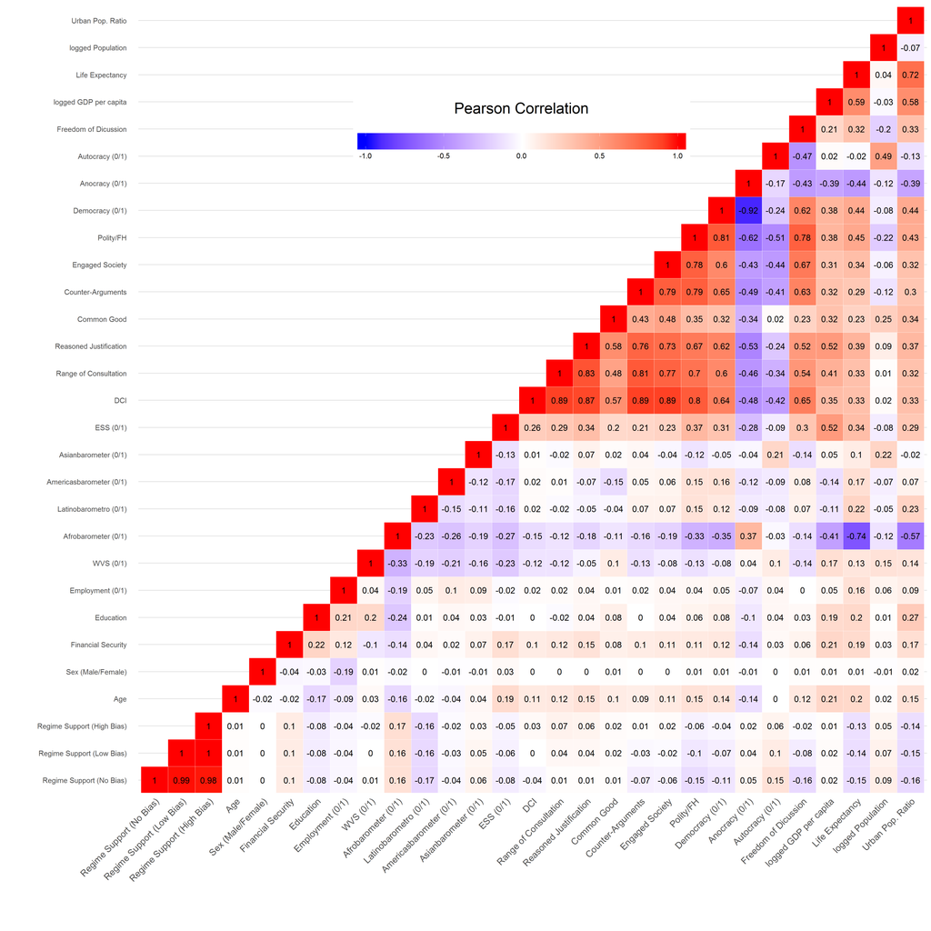

# Operationalization Regime Support

Table A3: Operationalization of Regime Support

| Survey and Questions | Support Object | Answers | Item Code |
| --- | --- | --- | --- |
| Afrobarometer Round 5/6 |  |  |  |
| How much do you trust each of the following, or haven’t you heard enough about them to say: | ... the President/Prime Minister ... Parliament ... the Police ... courts of law | not at all (0) just a little (1) somewhat (2) a lot (3) | Q59A/Q52A Q59B/Q52B Q59H/Q52H Q59J/Q52J |
| AmericasBarometer |  |  |  |
| To what extent do you trust… | ... the President/Prime Minister? ... the National Congress? ... the National Police? ... the justice system? | not at all (1) - a lot (7) | B21A B13 B18 B10A |
| Asian Barometer Wave 3/4 |  |  |  |
| I’m going to name a number of institutions. For each one, please tell me how much trust do you have in them? | ... the National Government ... Parliament ... the Police ... the courts | a great deal (1) quite a lot (2) not very much (3) none at all (4) | q9 q11 q14 q8 |
| Using this card, please tell me on a score of 0-10 how much you, personally trust each of the institutions I read out. 0 means you do not trust, an institution at all, and 10 means you have complete t… | ... politicians? ... [country]'s parliament? ... the police? ... the legal system? | No trust at all (0) - Complete trust (10) | trstplt trstprl trstplc trstlgl |
| Latinobarómetro 2013/2015 |  |  |  |
| Please look at this card and tell me how much trust you have in each of the following groups/institutions. | ... the National Government ... National Congress/Parliament ... Police ... Judiciary | a lot (1) some (2) a little(3) none (4) | P26STGBS.B/P16ST.G P26STGBS.C/P16ST.F Q28STGBS.B/P16TGB.B P26STGBS.E/P16ST.H |
| World Values Survey Wave 6 |  |  |  |
| I'm going to name a number of organizations. For each one, could you tell me how much confidence you have in them: | ... the Government [in capital] ... Parliament ... the Police ... the Courts | a great deal (1) quite a lot (2) not very much (3) none at all (4) | V115 |

# Control Variables

Table A4: Control Variables

| Variables | Origin | Notes |
| --- | --- | --- |
| Individual-Level Controls |  |  |
| Financial Security | Multiple Data Sources | Household Income/ Sufficient resources to support household |
| Education | Multiple Data Sources | Years of schooling/ education levels |
| Employment (0/1) | Multiple Data Sources | Dummy variable coded: 1 = Employed, 0 = Unemployed |
| Age | Multiple Data Sources | - |
| Sex (Male/Female) | Multiple Data Sources | Dummy variable coded: 1 = Female, 0 = Male |
| Regime Support | Multiple Data Sources | Index created with Principal Component Analysis |
| Country-Level Controls |  |  |
| Polity/FH | V-Dem | Imputed variable from Polity IV & Freedom House |
| Democracy (0/1)* | V-Dem | Dummy variable coded: 1 = Democracy, 0 = Non-Democracy |
| Autocracy (0/1)* | V-Dem | Dummy variable coded: 1 = Autocracy, 0 = Non-Autocracy |
| Life Expectancy | V-Dem/QoG | Average total life expectancy |
| logged Population | V-Dem/QoG | Population size |
| logged GDP per Capita | QoG | Real GDP per capita in constant dollars of the year 2000 (logged) |
| Urban Population Ratio | V-Dem/QoG | Percentage of Urban Population |
| Dataset Dummies Controls** |  |  |
| Afrobarometer (0/1) | Afrobarometer | Dummy variable coded: 1 = Afrobarometer data, 0 = Other Datasets |
| Latinobarometro (0/1) | Latinobarometro | Dummy variable coded: 1 = Latinobarometro data, 0 = Other Datasets |
| Americasbarometer (0/1) | Americasbarometer | Dummy variable coded: 1 = Americasbarometer data, 0 = Other Datasets |
| Asianbarometer (0/1) | Asianbarometer | Dummy variable coded: 1 = Asianbarometer data, 0 = Other Datasets |
| European Social Survey (0/1) | European Social Survey | Dummy variable coded: 1 = European Social Survey data, 0 = Other Datasets |

*Reference Category: Anocracies

** Reference Category: World Value Survey

# Country List

Table A5: Country Table

| Country | ISO Code | Nr. |
| --- | --- | --- |
| Albania | ALB | 1 |
| Algeria | DZA | 2 |
| Argentina | ARG | 3 |
| Armenia | ARM | 4 |
| Australia | AUS | 5 |
| Azerbaijan | AZE | 6 |
| Belarus | BLR | 7 |
| Belgium | BEL | 8 |
| Benin | BEN | 9 |
| Bolivia | BOL | 10 |
| Botswana | BWA | 11 |
| Brazil | BRA | 12 |
| Bulgaria | BGR | 13 |
| Burkina Faso | BFA | 14 |
| Burundi | BDI | 15 |
| Cambodia | KHM | 16 |
| Cameroon | CMR | 17 |
| Canada | CAN | 18 |
| Cape Verde | CPV | 19 |
| Chile | CHL | 20 |
| China | CHN | 21 |
| Colombia | COL | 22 |
| Costa Rica | CRI | 23 |
| Côte d’Ivoire | CIV | 24 |
| Cyprus | CYP | 25 |
| Czechia | CZE | 26 |
| Denmark | DNK | 27 |
| Dominican Republic | DOM | 28 |
| Ecuador | ECU | 29 |
| El Salvador | SLV | 30 |

[output cut: 89 more lines]

# Complete Sample: Statistical models A1.1 to F1.3

Table A5: Complete Sample: Statistical models A1.1 to F1.3

|  | DCI |  |  | Reasoned Justification |  |  | Common Good |  |  | Counter-Arguments |  |  | Range of Consultation |  |  | Engaged Society |  |  |  |
| --- | --- | --- | --- | --- | --- | --- | --- | --- | --- | --- | --- | --- | --- | --- | --- | --- | --- | --- | --- |
|  | Model A1.1 No Bias | Model A1.2 Low Bias | Model A1.3 High Bias | Model B1.1 No Bias | Model B1.2 Low Bias | Model B1.3 High Bias | Model C1.1 No Bias | Model C1.2 Low Bias | Model C1.3 High Bias | Model D1.1 No Bias | Model D1.2 Low Bias | Model D1.3 High Bias | Model E1.1 No Bias | Model E1.2 Low Bias | Model E1.3 High Bias | Model F1.1 No Bias | Model F1.2 Low Bias | Model F1.3 High Bias |  |
| Intercept | **.62***** | **.56***** | **.51***** | **.59***** | **.54***** | **.50***** | **.57***** | **.53***** | **.51***** | **.62***** | **.57***** | **.52***** | **.59***** | **.54***** | **.50***** | **.62***** | **.56***** | **.52***** |  |
|  | (.04) | (.03) | (.03) | (.04) | (.03) | (.03) | (.04) | (.03) | (.03) | (.04) | (.03) | (.03) | (.03) | (.03) | (.03) | (.03) | (.03) | (.03) |  |
| **Individual-Level Control Variables** |  |  |  |  |  |  |  |  |  |  |  |  |  |  |  |  |  |  |  |
| Financial Security | **.11***** | **.11***** | **.11***** | **.11***** | **.11***** | **.11***** | **.11***** | **.11***** | **.11***** | **.11***** | **.11***** | **.11***** | **.11***** | **.11***** | **.11***** | **.11***** | **.11***** | **.11***** |  |
|  | (.00) | (.00) | (.00) | (.00) | (.00) | (.00) | (.00) | (.00) | (.00) | (.00) | (.00) | (.00) | (.00) | (.00) | (.00) | (.00) | (.00) | (.00) |  |
| Education | **-.04***** | **-.04***** | **-.04***** | **-.04***** | **-.04***** | **-.04***** | **-.04***** | **-.04***** | **-.04***** | **-.04***** | **-.04***** | **-.04***** | **-.04***** | **-.04***** | **-.04***** | **-.04***** | **-.04***** | **-.04***** |  |
|  | (.00) | (.00) | (.00) | (.00) | (.00) | (.00) | (.00) | (.00) | (.00) | (.00) | (.00) | (.00) | (.00) | (.00) | (.00) | (.00) | (.00) | (.00) |  |
| Employment (0/1) | **-.01***** | **-.01***** | **-.01***** | **-.01***** | **-.01***** | **-.01***** | **-.01***** | **-.01***** | **-.01***** | **-.01***** | **-.01***** | **-.01***** | **-.01***** | **-.01***** | **-.01***** | **-.01***** | **-.01***** | **-.01***** |  |
|  | (.00) | (.00) | (.00) | (.00) | (.00) | (.00) | (.00) | (.00) | (.00) | (.00) | (.00) | (.00) | (.00) | (.00) | (.00) | (.00) | (.00) | (.00) |  |
| Age | **.04***** | **.04***** | **.04***** | **.04***** | **.04***** | **.04***** | **.04***** | **.04***** | **.04***** | **.04***** | **.04***** | **.04***** | **.04***** | **.04***** | **.04***** | **.04***** | **.04***** | **.04***** |  |
|  | (.00) | (.00) | (.00) | (.00) | (.00) | (.00) | (.00) | (.00) | (.00) | (.00) | (.00) | (.00) | (.00) | (.00) | (.00) | (.00) | (.00) | (.00) |  |
| Sex (Male/Female) | **.00***** | **.00***** | **.00***** | **.00***** | **.00***** | **.00***** | **.00***** | **.00***** | **.00***** | **.00***** | **.00***** | **.00***** | **.00***** | **.00***** | **.00***** | **.00***** | **.00***** | **.00***** |  |
|  | (.00) | (.00) | (.00) | (.00) | (.00) | (.00) | (.00) | (.00) | (.00) | (.00) | (.00) | (.00) | (.00) | (.00) | (.00) | (.00) | (.00) | (.00) |  |
| **Country-Level Control Variables** |  |  |  |  |  |  |  |  |  |  |  |  |  |  |  |  |  |  |  |
| logged Population | **.23*** | **.18**<sup>^</sup> | .13 | **.21**<sup>^</sup> | .16 | .11 | **.19**<sup>^</sup> | .15 | .10 | **.22*** | **.18**<sup>^</sup> | .15 | **.21**<sup>^</sup> | **.17**<sup>^</sup> | .13 | **.22*** | **.18**<sup>^</sup> | .14 |  |
|  | (.11) | (.10) | (.10) | (.11) | (.10) | (.10) | (.11) | (.10) | (.10) | (.11) | (.10) | (.10) | (.11) | (.10) | (.10) | (.11) | (.10) | (.10) |  |
| logged GDP per capita | **.65***** | **.55***** | **.49***** | **.63***** | **.50***** | **.42***** | **.61***** | **.53***** | **.48***** | **.65***** | **.56***** | **.50***** | **.63***** | **.52***** | **.45***** | **.64***** | **.55***** | **.50***** |  |
|  | (.11) | (.10) | (.10) | (.11) | (.11) | (.10) | (.11) | (.10) | (.10) | (.11) | (.10) | (.10) | (.11) | (.10) | (.10) | (.11) | (.10) | (.10) |  |
| Life Expectancy | **-.18**** | **-.18**** | **-.18***** | **-.19***** | **-.18***** | **-.19***** | **-.19***** | **-.17**** | **-.16**** | **-.18**** | **-.17**** | **-.17**** | **-.19***** | **-.18***** | **-.18***** | **-.18**** | **-.18**** | **-.18***** |  |
|  | (.06) | (.05) | (.05) | (.06) | (.05) | (.05) | (.06) | (.05) | (.05) | (.06) | (.05) | (.05) | (.06) | (.05) | (.05) | (.06) | (.05) | (.05) |  |
| Urban Pop. Ratio | **-.15*** | **-.13*** | **-.11*** | **-.16**** | **-.13*** | **-.11**<sup>^</sup> | **-.17**** | **-.15*** | **-.13*** | **-.16**** | **-.13*** | **-.11**<sup>^</sup> | **-.16**** | **-.13*** | **-.11*** | **-.16**** | **-.13*** | **-.11*** |  |
|  | (.06) | (.06) | (.06) | (.06) | (.06) | (.06) | (.06) | (.06) | (.06) | (.06) | (.06) | (.06) | (.06) | (.06) | (.05) | (.06) | (.06) | (.06) |  |
| **Dataset Control Dummies** |  |  |  |  |  |  |  |  |  |  |  |  |  |  |  |  |  |  |  |
| Afrobarometer (0/1) | -.00 | -.00 | -.00 | -.00 | -.00 | -.00 | -.00 | -.00 | -.00 | -.00 | -.00 | -.00 | -.00 | -.00 | -.00 | -.00 | -.00 | -.00 |  |
|  | (.00) | (.00) | (.00) | (.00) | (.00) | (.00) | (.00) | (.00) | (.00) | (.00) | (.00) | (.00) | (.00) | (.00) | (.00) | (.00) | (.00) | (.00) |  |
| Latinobarometro (0/1) | **-.03***** | **-.03***** | **-.03***** | **-.03***** | **-.03***** | **-.03***** | **-.03***** | **-.03***** | **-.03***** | **-.03***** | **-.03***** | **-.03***** | **-.03***** | **-.03***** | **-.03***** | **-.03***** | **-.03***** | **-.03***** |  |
|  | (.00) | (.00) | (.00) | (.00) | (.00) | (.00) | (.00) | (.00) | (.00) | (.00) | (.00) | (.00) | (.00) | (.00) | (.00) | (.00) | (.00) | (.00) |  |
| Americasbarometer (0/1) | **.07***** | **.07***** | **.07***** | **.07***** | **.07***** | **.07***** | **.07***** | **.07***** | **.07***** | **.07***** | **.07***** | **.07***** | **.07***** | **.07***** | **.07***** | **.07***** | **.07***** | **.07***** |  |
|  | (.00) | (.00) | (.00) | (.00) | (.00) | (.00) | (.00) | (.00) | (.00) | (.00) | (.00) | (.00) | (.00) | (.00) | (.00) | (.00) | (.00) | (.00) |  |
| Asianbarometer (0/1) | **-.05***** | **-.05***** | **-.05***** | **-.05***** | **-.05***** | **-.05***** | **-.05***** | **-.05***** | **-.05***** | **-.05***** | **-.05***** | **-.05***** | **-.05***** | **-.05***** | **-.05***** | **-.05***** | **-.05***** | **-.05***** |  |
|  | (.00) | (.00) | (.00) | (.00) | (.00) | (.00) | (.00) | (.00) | (.00) | (.00) | (.00) | (.00) | (.00) | (.00) | (.00) | (.00) | (.00) | (.00) |  |
| ESS (0/1) | **-.07***** | **-.07***** | **-.07***** | **-.07***** | **-.07***** | **-.07***** | **-.07***** | **-.07***** | **-.07***** | **-.07***** | **-.07***** | **-.07***** | **-.07***** | **-.07***** | **-.07***** | **-.07***** | **-.07***** | **-.07***** |  |
|  | (.00) | (.00) | (.00) | (.00) | (.00) | (.00) | (.00) | (.00) | (.00) | (.00) | (.00) | (.00) | (.00) | (.00) | (.00) | (.00) | (.00) | (.00) |  |
| **DCI & Subcomponents** |  |  |  |  |  |  |  |  |  |  |  |  |  |  |  |  |  |  |  |
| DCI | -.05 | .02 | **.07**<sup>^</sup> |  |  |  |  |  |  |  |  |  |  |  |  |  |  |  |  |
|  | (.04) | (.04) | (.04) |  |  |  |  |  |  |  |  |  |  |  |  |  |  |  |  |
| Reasoned Justification |  |  |  | .00 | .08 | **.13**** |  |  |  |  |  |  |  |  |  |  |  |  |  |
|  |  |  |  | (.06) | (.05) | (.05) |  |  |  |  |  |  |  |  |  |  |  |  |  |
| Common Good |  |  |  |  |  |  | .05 | .07 | **.09**<sup>^</sup> |  |  |  |  |  |  |  |  |  |  |
|  |  |  |  |  |  |  | (.05) | (.05) | (.05) |  |  |  |  |  |  |  |  |  |  |
| Counter-Arguments |  |  |  |  |  |  |  |  |  | -.07 | .00 | .05 |  |  |  |  |  |  |  |
|  |  |  |  |  |  |  |  |  |  | (.05) | (.04) | (.04) |  |  |  |  |  |  |  |
| Range of Consultation |  |  |  |  |  |  |  |  |  |  |  |  | .01 | .08 | **.14**** |  |  |  |  |
|  |  |  |  |  |  |  |  |  |  |  |  |  | (.06) | (.05) | (.05) |  |  |  |  |
| Engaged Society |  |  |  |  |  |  |  |  |  |  |  |  |  |  |  | -.07 | .01 | .07 |  |
|  |  |  |  |  |  |  |  |  |  |  |  |  |  |  |  | (.05) | (.05) | (.05) |  |
| AIC | $26153.61$ | $15143.51$ | $6595.63$ | $26154.46$ | $15141.00$ | $6591.53$ | $26153.80$ | $15141.22$ | $6594.80$ | $26152.76$ | $15143.57$ | $6597.20$ | $26154.45$ | $15140.83$ | $6591.14$ | $26152.76$ | $15143.33$ | $6596.04$ |  |
| BIC | $26345.61$ | $15335.51$ | $6787.63$ | $26346.45$ | $15332.99$ | $6783.52$ | $26345.79$ | $15333.21$ | $6786.80$ | $26344.75$ | $15335.56$ | $6789.20$ | $26346.44$ | $15332.82$ | $6783.14$ | $26344.76$ | $15335.32$ | $6788.04$ |  |
| Log Likelihood | $-13058.80$ | $-7553.75$ | $-3279.82$ | $-13059.23$ | $-7552.50$ | $-3277.76$ | $-13058.90$ | $-7552.61$ | $-3279.40$ | $-13058.38$ | $-7553.78$ | $-3280.60$ | $-13059.22$ | $-7552.41$ | $-3277.57$ | $-13058.38$ | $-7553.66$ | $-3280.02$ |  |
| Num. obs. | $316938$ | $316938$ | $316938$ | $316938$ | $316938$ | $316938$ | $316938$ | $316938$ | $316938$ | $316938$ | $316938$ | $316938$ | $316938$ | $316938$ | $316938$ | $316938$ | $316938$ | $316938$ |  |
| Num. groups: cntry | $119$ | $119$ | $119$ | $119$ | $119$ | $119$ | $119$ | $119$ | $119$ | $119$ | $119$ | $119$ | $119$ | $119$ | $119$ | $119$ | $119$ | $119$ |  |
| Var: cntry (Intercept) | $0.01$ | $0.01$ | $0.01$ | $0.01$ | $0.01$ | $0.01$ | $0.01$ | $0.01$ | $0.01$ | $0.01$ | $0.01$ | $0.01$ | $0.01$ | $0.01$ | $0.01$ | $0.01$ | $0.01$ | $0.01$ |  |
| Var: Residual | $0.02$ | $0.02$ | $0.02$ | $0.02$ | $0.02$ | $0.02$ | $0.02$ | $0.02$ | $0.02$ | $0.02$ | $0.02$ | $0.02$ | $0.02$ | $0.02$ | $0.02$ | $0.02$ | $0.02$ | $0.02$ |  |
| ***p < 0.001, **p < 0.01, *p < 0.05, ^p < 0.1. Models show unstandardized b-coefficients and all predictors are normalized from 0 to 1. Reference category for dataset dummies is World Value Survey. Mo… |  |  |  |  |  |  |  |  |  |  |  |  |  |  |  |  |  |  |  |

# Complete Sample (including Polity/FH dummies): Statistical models A1.4 to F1.6

Table A6: Complete Sample (including Polity/FH dummies): Statistical models A1.4 to F1.6

|  | DCI |  |  | Reasoned Justification |  |  | Common Good |  |  | Counter-Arguments |  |  | Range of Consultation |  |  | Engaged Society |  |  |  |
| --- | --- | --- | --- | --- | --- | --- | --- | --- | --- | --- | --- | --- | --- | --- | --- | --- | --- | --- | --- |
|  | Model A1.4 No Bias | Model A1.5 Low Bias | Model A1.6 High Bias | Model B1.4 No Bias | Model B1.5 Low Bias | Model B1.6 High Bias | Model C1.4 No Bias | Model C1.5 Low Bias | Model C1.6 High Bias | Model D1.4 No Bias | Model D1.5 Low Bias | Model D1.6 High Bias | Model E1.4 No Bias | Model E1.5 Low Bias | Model E1.6 High Bias | Model F1.4 No Bias | Model F1.5 Low Bias | Model F1.6 High Bias |  |
| Intercept | **.50***** | **.47***** | **.44***** | **.50***** | **.47***** | **.45***** | **.54***** | **.51***** | **.50***** | **.54***** | **.51***** | **.49***** | **.49***** | **.46***** | **.44***** | **.53***** | **.50***** | **.47***** |  |
|  | (.04) | (.04) | (.04) | (.04) | (.04) | (.04) | (.04) | (.03) | (.03) | (.04) | (.04) | (.04) | (.04) | (.04) | (.04) | (.04) | (.04) | (.04) |  |
| **Individual-Level Control Variables** |  |  |  |  |  |  |  |  |  |  |  |  |  |  |  |  |  |  |  |
| Financial Security | **.11***** | **.11***** | **.11***** | **.11***** | **.11***** | **.11***** | **.11***** | **.11***** | **.11***** | **.11***** | **.11***** | **.11***** | **.11***** | **.11***** | **.11***** | **.11***** | **.11***** | **.11***** |  |
|  | (.00) | (.00) | (.00) | (.00) | (.00) | (.00) | (.00) | (.00) | (.00) | (.00) | (.00) | (.00) | (.00) | (.00) | (.00) | (.00) | (.00) | (.00) |  |
| Education | **-.04***** | **-.04***** | **-.04***** | **-.04***** | **-.04***** | **-.04***** | **-.04***** | **-.04***** | **-.04***** | **-.04***** | **-.04***** | **-.04***** | **-.04***** | **-.04***** | **-.04***** | **-.04***** | **-.04***** | **-.04***** |  |
|  | (.00) | (.00) | (.00) | (.00) | (.00) | (.00) | (.00) | (.00) | (.00) | (.00) | (.00) | (.00) | (.00) | (.00) | (.00) | (.00) | (.00) | (.00) |  |
| Employment (0/1) | **-.01***** | **-.01***** | **-.01***** | **-.01***** | **-.01***** | **-.01***** | **-.01***** | **-.01***** | **-.01***** | **-.01***** | **-.01***** | **-.01***** | **-.01***** | **-.01***** | **-.01***** | **-.01***** | **-.01***** | **-.01***** |  |
|  | (.00) | (.00) | (.00) | (.00) | (.00) | (.00) | (.00) | (.00) | (.00) | (.00) | (.00) | (.00) | (.00) | (.00) | (.00) | (.00) | (.00) | (.00) |  |
| Age | **.04***** | **.04***** | **.04***** | **.04***** | **.04***** | **.04***** | **.04***** | **.04***** | **.04***** | **.04***** | **.04***** | **.04***** | **.04***** | **.04***** | **.04***** | **.04***** | **.04***** | **.04***** |  |
|  | (.00) | (.00) | (.00) | (.00) | (.00) | (.00) | (.00) | (.00) | (.00) | (.00) | (.00) | (.00) | (.00) | (.00) | (.00) | (.00) | (.00) | (.00) |  |
| Sex (Male/Female) | **.00***** | **.00***** | **.00***** | **.00***** | **.00***** | **.00***** | **.00***** | **.00***** | **.00***** | **.00***** | **.00***** | **.00***** | **.00***** | **.00***** | **.00***** | **.00***** | **.00***** | **.00***** |  |
|  | (.00) | (.00) | (.00) | (.00) | (.00) | (.00) | (.00) | (.00) | (.00) | (.00) | (.00) | (.00) | (.00) | (.00) | (.00) | (.00) | (.00) | (.00) |  |
| **Country-Level Control Variables** |  |  |  |  |  |  |  |  |  |  |  |  |  |  |  |  |  |  |  |
| Democracy (0/1) | **-.05**<sup>^</sup> | -.04 | -.03 | **-.06*** | **-.04**<sup>^</sup> | -.03 | -.03 | -.01 | .00 | -.04 | -.02 | -.01 | **-.06*** | **-.04**<sup>^</sup> | -.03 | -.04 | -.03 | -.01 |  |
|  | (.03) | (.02) | (.02) | (.02) | (.02) | (.02) | (.02) | (.02) | (.02) | (.03) | (.03) | (.03) | (.02) | (.02) | (.02) | (.02) | (.02) | (.02) |  |
| Autocracy (0/1) | **.17***** | **.14**** | **.11*** | **.17***** | **.12**** | **.09*** | **.12**** | **.07**<sup>^</sup> | .04 | **.14**** | **.10*** | .07 | **.19***** | **.14***** | **.11**** | **.16***** | **.12**** | **.10*** |  |
|  | (.05) | (.05) | (.05) | (.04) | (.04) | (.04) | (.04) | (.04) | (.04) | (.04) | (.04) | (.04) | (.04) | (.04) | (.04) | (.05) | (.05) | (.05) |  |
| logged Population | .08 | .06 | .04 | .06 | .05 | .03 | .09 | .09 | .08 | .12 | .12 | .10 | .06 | .06 | .04 | .11 | .09 | .07 |  |
|  | (.11) | (.11) | (.11) | (.11) | (.10) | (.10) | (.11) | (.11) | (.11) | (.11) | (.10) | (.10) | (.10) | (.10) | (.10) | (.11) | (.10) | (.10) |  |
| logged GDP per capita | **.54***** | **.47***** | **.42***** | **.47***** | **.39***** | **.34**** | **.56***** | **.50***** | **.46***** | **.57***** | **.50***** | **.46***** | **.47***** | **.40***** | **.36***** | **.56***** | **.49***** | **.45***** |  |
|  | (.11) | (.10) | (.10) | (.11) | (.11) | (.11) | (.11) | (.10) | (.10) | (.11) | (.11) | (.11) | (.11) | (.10) | (.10) | (.11) | (.10) | (.10) |  |
| Life Expectancy | **-.17**** | **-.17**** | **-.17**** | **-.17**** | **-.17***** | **-.18***** | **-.16**** | **-.16**** | **-.16**** | **-.16**** | **-.16**** | **-.17**** | **-.17**** | **-.17**** | **-.17***** | **-.18**** | **-.18***** | **-.18***** |  |
|  | (.05) | (.05) | (.05) | (.05) | (.05) | (.05) | (.06) | (.05) | (.05) | (.06) | (.05) | (.05) | (.05) | (.05) | (.05) | (.06) | (.05) | (.05) |  |
| Urban Pop. Ratio | **-.13*** | **-.11*** | **-.09**<sup>^</sup> | **-.12*** | **-.10**<sup>^</sup> | -.09 | **-.15*** | **-.13*** | **-.12*** | **-.13*** | **-.11*** | **-.10**<sup>^</sup> | **-.11*** | **-.10**<sup>^</sup> | -.08 | **-.12*** | **-.11**<sup>^</sup> | -.09 |  |
|  | (.06) | (.06) | (.06) | (.06) | (.05) | (.05) | (.06) | (.06) | (.06) | (.06) | (.06) | (.06) | (.06) | (.05) | (.05) | (.06) | (.06) | (.06) |  |
| **Dataset Control Dummies** |  |  |  |  |  |  |  |  |  |  |  |  |  |  |  |  |  |  |  |
| Afrobarometer (0/1) | -.00 | -.00 | -.00 | -.00 | -.00 | -.00 | -.00 | -.00 | -.00 | -.00 | -.00 | -.00 | -.00 | -.00 | -.00 | -.00 | -.00 | -.00 |  |
|  | (.00) | (.00) | (.00) | (.00) | (.00) | (.00) | (.00) | (.00) | (.00) | (.00) | (.00) | (.00) | (.00) | (.00) | (.00) | (.00) | (.00) | (.00) |  |
| Latinobarometro (0/1) | **-.03***** | **-.03***** | **-.03***** | **-.03***** | **-.03***** | **-.03***** | **-.03***** | **-.03***** | **-.03***** | **-.03***** | **-.03***** | **-.03***** | **-.03***** | **-.03***** | **-.03***** | **-.03***** | **-.03***** | **-.03***** |  |
|  | (.00) | (.00) | (.00) | (.00) | (.00) | (.00) | (.00) | (.00) | (.00) | (.00) | (.00) | (.00) | (.00) | (.00) | (.00) | (.00) | (.00) | (.00) |  |
| Americasbarometer (0/1) | **.07***** | **.07***** | **.07***** | **.07***** | **.07***** | **.07***** | **.07***** | **.07***** | **.07***** | **.07***** | **.07***** | **.07***** | **.07***** | **.07***** | **.07***** | **.07***** | **.07***** | **.07***** |  |
|  | (.00) | (.00) | (.00) | (.00) | (.00) | (.00) | (.00) | (.00) | (.00) | (.00) | (.00) | (.00) | (.00) | (.00) | (.00) | (.00) | (.00) | (.00) |  |
| Asianbarometer (0/1) | **-.05***** | **-.05***** | **-.05***** | **-.05***** | **-.05***** | **-.05***** | **-.05***** | **-.05***** | **-.05***** | **-.05***** | **-.05***** | **-.05***** | **-.05***** | **-.05***** | **-.05***** | **-.05***** | **-.05***** | **-.05***** |  |
|  | (.00) | (.00) | (.00) | (.00) | (.00) | (.00) | (.00) | (.00) | (.00) | (.00) | (.00) | (.00) | (.00) | (.00) | (.00) | (.00) | (.00) | (.00) |  |
| ESS (0/1) | **-.07***** | **-.07***** | **-.07***** | **-.07***** | **-.07***** | **-.07***** | **-.07***** | **-.07***** | **-.07***** | **-.07***** | **-.07***** | **-.07***** | **-.07***** | **-.07***** | **-.07***** | **-.07***** | **-.07***** | **-.07***** |  |
|  | (.00) | (.00) | (.00) | (.00) | (.00) | (.00) | (.00) | (.00) | (.00) | (.00) | (.00) | (.00) | (.00) | (.00) | (.00) | (.00) | (.00) | (.00) |  |
| **DCI & Subcomponents** |  |  |  |  |  |  |  |  |  |  |  |  |  |  |  |  |  |  |  |
| DCI | **.12*** | **.15**** | **.17**** |  |  |  |  |  |  |  |  |  |  |  |  |  |  |  |  |
|  | (.06) | (.06) | (.06) |  |  |  |  |  |  |  |  |  |  |  |  |  |  |  |  |
| Reasoned Justification |  |  |  | **.19**** | **.21***** | **.23***** |  |  |  |  |  |  |  |  |  |  |  |  |  |
|  |  |  |  | (.07) | (.06) | (.06) |  |  |  |  |  |  |  |  |  |  |  |  |  |
| Common Good |  |  |  |  |  |  | **.09**<sup>^</sup> | **.09**<sup>^</sup> | **.09**<sup>^</sup> |  |  |  |  |  |  |  |  |  |  |
|  |  |  |  |  |  |  | (.05) | (.05) | (.05) |  |  |  |  |  |  |  |  |  |  |
| Counter-Arguments |  |  |  |  |  |  |  |  |  | .06 | .09 | **.11**<sup>^</sup> |  |  |  |  |  |  |  |
|  |  |  |  |  |  |  |  |  |  | (.06) | (.06) | (.06) |  |  |  |  |  |  |  |
| Range of Consultation |  |  |  |  |  |  |  |  |  |  |  |  | **.22***** | **.24***** | **.26***** |  |  |  |  |
|  |  |  |  |  |  |  |  |  |  |  |  |  | (.07) | (.06) | (.07) |  |  |  |  |
| Engaged Society |  |  |  |  |  |  |  |  |  |  |  |  |  |  |  | .10 | **.14*** | **.17*** |  |
|  |  |  |  |  |  |  |  |  |  |  |  |  |  |  |  | (.07) | (.07) | (.07) |  |
| AIC | $26151.73$ | $15146.87$ | $6602.84$ | $26147.91$ | $15142.69$ | $6599.07$ | $26153.28$ | $15150.72$ | $6608.36$ | $26154.70$ | $15151.45$ | $6608.47$ | $26145.02$ | $15140.11$ | $6596.66$ | $26153.36$ | $15149.02$ | $6605.10$ |  |
| BIC | $26365.06$ | $15360.20$ | $6816.17$ | $26361.24$ | $15356.02$ | $6812.40$ | $26366.61$ | $15364.05$ | $6821.69$ | $26368.03$ | $15364.78$ | $6821.80$ | $26358.35$ | $15353.44$ | $6809.99$ | $26366.69$ | $15362.35$ | $6818.43$ |  |
| Log Likelihood | $-13055.87$ | $-7553.43$ | $-3281.42$ | $-13053.96$ | $-7551.35$ | $-3279.53$ | $-13056.64$ | $-7555.36$ | $-3284.18$ | $-13057.35$ | $-7555.73$ | $-3284.24$ | $-13052.51$ | $-7550.06$ | $-3278.33$ | $-13056.68$ | $-7554.51$ | $-3282.55$ |  |
| Num. obs. | $316938$ | $316938$ | $316938$ | $316938$ | $316938$ | $316938$ | $316938$ | $316938$ | $316938$ | $316938$ | $316938$ | $316938$ | $316938$ | $316938$ | $316938$ | $316938$ | $316938$ | $316938$ |  |
| Num. groups: cntry | $119$ | $119$ | $119$ | $119$ | $119$ | $119$ | $119$ | $119$ | $119$ | $119$ | $119$ | $119$ | $119$ | $119$ | $119$ | $119$ | $119$ | $119$ |  |
| Var: cntry (Intercept) | $0.01$ | $0.01$ | $0.01$ | $0.01$ | $0.01$ | $0.01$ | $0.01$ | $0.01$ | $0.01$ | $0.01$ | $0.01$ | $0.01$ | $0.01$ | $0.01$ | $0.01$ | $0.01$ | $0.01$ | $0.01$ |  |
| Var: Residual | $0.02$ | $0.02$ | $0.02$ | $0.02$ | $0.02$ | $0.02$ | $0.02$ | $0.02$ | $0.02$ | $0.02$ | $0.02$ | $0.02$ | $0.02$ | $0.02$ | $0.02$ | $0.02$ | $0.02$ | $0.02$ |  |
| ***p < 0.001, **p < 0.01, *p < 0.05, ^p < 0.1. Models show unstandardized b-coefficients and all predictors are normalized from 0 to 1. Reference category for dataset dummies is World Value Survey. Re… |  |  |  |  |  |  |  |  |  |  |  |  |  |  |  |  |  |  |  |

# Democracy Sample: Statistical models A2.1 to F2.2

Table A7: Democracy Sample: Statistical models A2.1 to F2.2

|  | DCI |  | Reasoned Justification |  | Common Good |  | Counter-Arguments |  | Range of Consultation |  | Engaged Society |  |  |
| --- | --- | --- | --- | --- | --- | --- | --- | --- | --- | --- | --- | --- | --- |
|  | *Model A2.1* | Model A2.2 (Polity/FH) | *Model B2.1* | Model B2.2 (Polity/FH) | *Model C2.1* | Model C2.2 (Polity/FH) | *Model D2.1* | Model D2.2 (Polity/FH) | *Model E2.1* | Model E2.2 (Polity/FH) | *Model F2.1* | Model F2.2 (Polity/FH) |  |
| Intercept | **.52***** | **.51***** | **.53***** | **.52***** | **.57***** | **.57***** | **.56***** | **.56***** | **.55***** | **.55***** | **.55***** | **.55***** |  |
|  | (.05) | (.05) | (.04) | (.04) | (.05) | (.05) | (.05) | (.05) | (.04) | (.04) | (.04) | (.04) |  |
| **Individual-Level Control Variables** |  |  |  |  |  |  |  |  |  |  |  |  |  |
| Financial Security | **.10***** | **.10***** | **.10***** | **.10***** | **.10***** | **.10***** | **.10***** | **.10***** | **.10***** | **.10***** | **.10***** | **.10***** |  |
|  | (.00) | (.00) | (.00) | (.00) | (.00) | (.00) | (.00) | (.00) | (.00) | (.00) | (.00) | (.00) |  |
| Education | .00 | .00 | .00 | .00 | .00 | .00 | .00 | .00 | .00 | .00 | .00 | .00 |  |
|  | (.00) | (.00) | (.00) | (.00) | (.00) | (.00) | (.00) | (.00) | (.00) | (.00) | (.00) | (.00) |  |
| Employment (0/1) | **-.01***** | **-.01***** | **-.01***** | **-.01***** | **-.01***** | **-.01***** | **-.01***** | **-.01***** | **-.01***** | **-.01***** | **-.01***** | **-.01***** |  |
|  | (.00) | (.00) | (.00) | (.00) | (.00) | (.00) | (.00) | (.00) | (.00) | (.00) | (.00) | (.00) |  |
| Age | **.03***** | **.03***** | **.03***** | **.03***** | **.03***** | **.03***** | **.03***** | **.03***** | **.03***** | **.03***** | **.03***** | **.03***** |  |
|  | (.00) | (.00) | (.00) | (.00) | (.00) | (.00) | (.00) | (.00) | (.00) | (.00) | (.00) | (.00) |  |
| Sex (Male/Female) | **.00***** | **.00***** | **.00***** | **.00***** | **.00***** | **.00***** | **.00***** | **.00***** | **.00***** | **.00***** | **.00***** | **.00***** |  |
|  | (.00) | (.00) | (.00) | (.00) | (.00) | (.00) | (.00) | (.00) | (.00) | (.00) | (.00) | (.00) |  |
| **Country-Level Control Variables** |  |  |  |  |  |  |  |  |  |  |  |  |  |
| logged Population | .02 | -.01 | .04 | .02 | .08 | .07 | .04 | .00 | .05 | .02 | .05 | .04 |  |
|  | (.12) | (.11) | (.11) | (.11) | (.12) | (.12) | (.12) | (.12) | (.11) | (.11) | (.11) | (.11) |  |
| logged GDP per capita | **.30***** | **.39***** | **.22*** | **.29**** | **.36***** | **.40***** | **.36***** | **.45***** | **.26**** | **.35***** | **.30***** | **.35***** |  |
|  | (.09) | (.10) | (.09) | (.10) | (.09) | (.11) | (.08) | (.10) | (.08) | (.09) | (.08) | (.10) |  |
| Life Expectancy | **-.36***** | **-.34***** | **-.38***** | **-.37***** | **-.37***** | **-.36***** | **-.38***** | **-.37***** | **-.36***** | **-.34***** | **-.37***** | **-.36***** |  |
|  | (.07) | (.07) | (.07) | (.07) | (.07) | (.08) | (.07) | (.07) | (.07) | (.07) | (.07) | (.07) |  |
| Urban Pop. Ratio | -.00 | -.01 | .04 | .04 | .01 | .01 | .02 | .02 | .01 | .01 | .01 | .02 |  |
|  | (.07) | (.07) | (.06) | (.06) | (.07) | (.07) | (.07) | (.07) | (.06) | (.06) | (.06) | (.06) |  |
| Polity/FH |  | **-.09**<sup>^</sup> |  | **-.08**<sup>^</sup> |  | -.03 |  | -.08 |  | **-.09**<sup>^</sup> |  | -.04 |  |
|  |  | (.05) |  | (.04) |  | (.05) |  | (.05) |  | (.04) |  | (.04) |  |
| **Dataset Control Dummies** |  |  |  |  |  |  |  |  |  |  |  |  |  |
| Afrobarometer (0/1) | **-.02***** | **-.02***** | **-.02***** | **-.02**** | **-.02**** | **-.02**** | **-.02**** | **-.02**** | **-.02***** | **-.02***** | **-.02**** | **-.02**** |  |
|  | (.01) | (.01) | (.01) | (.01) | (.01) | (.01) | (.01) | (.01) | (.01) | (.01) | (.01) | (.01) |  |
| Latinobarometro (0/1) | **-.03***** | **-.03***** | **-.03***** | **-.04***** | **-.03***** | **-.03***** | **-.03***** | **-.04***** | **-.04***** | **-.04***** | **-.04***** | **-.04***** |  |
|  | (.00) | (.00) | (.00) | (.00) | (.00) | (.00) | (.00) | (.00) | (.00) | (.00) | (.00) | (.00) |  |
| Americasbarometer (0/1) | **.06***** | **.06***** | **.06***** | **.06***** | **.06***** | **.06***** | **.06***** | **.06***** | **.06***** | **.06***** | **.06***** | **.06***** |  |
|  | (.00) | (.00) | (.00) | (.00) | (.00) | (.00) | (.00) | (.00) | (.00) | (.00) | (.00) | (.00) |  |
| Asianbarometer (0/1) | **-.11***** | **-.11***** | **-.11***** | **-.11***** | **-.11***** | **-.11***** | **-.11***** | **-.11***** | **-.11***** | **-.11***** | **-.11***** | **-.11***** |  |
|  | (.00) | (.00) | (.00) | (.00) | (.00) | (.00) | (.00) | (.00) | (.00) | (.00) | (.00) | (.00) |  |
| ESS (0/1) | **-.05***** | **-.05***** | **-.05***** | **-.05***** | **-.05***** | **-.05***** | **-.05***** | **-.05***** | **-.05***** | **-.05***** | **-.05***** | **-.05***** |  |
|  | (.00) | (.00) | (.00) | (.00) | (.00) | (.00) | (.00) | (.00) | (.00) | (.00) | (.00) | (.00) |  |
| **DCI & Subcomponents** |  |  |  |  |  |  |  |  |  |  |  |  |  |
| DCI | **.16**** | **.21***** |  |  |  |  |  |  |  |  |  |  |  |
|  | (.05) | (.06) |  |  |  |  |  |  |  |  |  |  |  |
| Reasoned Justification |  |  | **.23***** | **.27***** |  |  |  |  |  |  |  |  |  |
|  |  |  | (.06) | (.06) |  |  |  |  |  |  |  |  |  |
| Common Good |  |  |  |  | .07 | .09 |  |  |  |  |  |  |  |
|  |  |  |  |  | (.06) | (.06) |  |  |  |  |  |  |  |
| Counter-Arguments |  |  |  |  |  |  | **.12*** | **.16**** |  |  |  |  |  |
|  |  |  |  |  |  |  | (.05) | (.06) |  |  |  |  |  |
| Range of Consultation |  |  |  |  |  |  |  |  | **.22***** | **.26***** |  |  |  |
|  |  |  |  |  |  |  |  |  | (.06) | (.06) |  |  |  |
| Engaged Society |  |  |  |  |  |  |  |  |  |  | **.17***** | **.18***** |  |
|  |  |  |  |  |  |  |  |  |  |  | (.05) | (.05) |  |
| AIC | $-10949.52$ | $-10946.60$ | $-10954.81$ | $-10951.68$ | $-10942.54$ | $-10936.84$ | $-10946.05$ | $-10942.47$ | $-10954.23$ | $-10951.54$ | $-10951.43$ | $-10945.93$ |  |
| BIC | $-10768.05$ | $-10755.06$ | $-10773.34$ | $-10760.13$ | $-10761.08$ | $-10745.30$ | $-10764.59$ | $-10750.93$ | $-10772.77$ | $-10759.99$ | $-10769.97$ | $-10754.39$ |  |
| Log Likelihood | $5492.76$ | $5492.30$ | $5495.40$ | $5494.84$ | $5489.27$ | $5487.42$ | $5491.03$ | $5490.24$ | $5495.12$ | $5494.77$ | $5493.72$ | $5491.97$ |  |
| Num. obs. | $176552$ | $176552$ | $176552$ | $176552$ | $176552$ | $176552$ | $176552$ | $176552$ | $176552$ | $176552$ | $176552$ | $176552$ |  |
| Num. groups: cntry | $64$ | $64$ | $64$ | $64$ | $64$ | $64$ | $64$ | $64$ | $64$ | $64$ | $64$ | $64$ |  |
| Var: cntry (Intercept) | $0.01$ | $0.01$ | $0.01$ | $0.01$ | $0.01$ | $0.01$ | $0.01$ | $0.01$ | $0.01$ | $0.01$ | $0.01$ | $0.01$ |  |
| Var: Residual | $0.01$ | $0.01$ | $0.01$ | $0.01$ | $0.01$ | $0.01$ | $0.01$ | $0.01$ | $0.01$ | $0.01$ | $0.01$ | $0.01$ |  |
| ***p < 0.001, **p < 0.01, *p < 0.05, ^p < 0.1. Models show unstandardized b-coefficients and all predictors are normalized from 0 to 1. Reference category for dataset dummies is World Value Survey. Mo… |  |  |  |  |  |  |  |  |  |  |  |  |  |

# Non-Democracies Sample: Statistical models A3.1 to F3.3

Table A8: Non-Democracies Sample: Statistical models A3.1 to F3.3

|  | DCI |  |  | Reasoned Justification |  |  | Common Good |  |  | Counter-Arguments |  |  | Range of Consultation |  |  | Engaged Society |  |  |  |
| --- | --- | --- | --- | --- | --- | --- | --- | --- | --- | --- | --- | --- | --- | --- | --- | --- | --- | --- | --- |
|  | Model A3.1 No Bias | Model A3.2 Low Bias | Model A3.3 High Bias | Model B3.1 No Bias | Model B3.2 Low Bias | Model B3.3 High Bias | Model C3.1 No Bias | Model C3.2 Low Bias | Model C3.3 High Bias | Model D3.1 No Bias | Model D3.2 Low Bias | Model D3.3 High Bias | Model E3.1 No Bias | Model E3.2 Low Bias | Model E3.3 High Bias | Model F3.1 No Bias | Model F3.2 Low Bias | Model F3.3 High Bias |  |
| Intercept | **.60***** | **.54***** | **.50***** | **.58***** | **.52***** | **.48***** | **.53***** | **.50***** | **.47***** | **.62***** | **.56***** | **.51***** | **.59***** | **.54***** | **.50***** | **.63***** | **.57***** | **.53***** |  |
|  | (.05) | (.05) | (.05) | (.05) | (.05) | (.05) | (.05) | (.04) | (.05) | (.05) | (.05) | (.05) | (.05) | (.05) | (.05) | (.05) | (.04) | (.04) |  |
| **Individual-Level Control Variables** |  |  |  |  |  |  |  |  |  |  |  |  |  |  |  |  |  |  |  |
| Financial Security | **.13***** | **.13***** | **.12***** | **.13***** | **.13***** | **.12***** | **.13***** | **.13***** | **.12***** | **.13***** | **.13***** | **.12***** | **.13***** | **.13***** | **.12***** | **.13***** | **.13***** | **.12***** |  |
|  | (.00) | (.00) | (.00) | (.00) | (.00) | (.00) | (.00) | (.00) | (.00) | (.00) | (.00) | (.00) | (.00) | (.00) | (.00) | (.00) | (.00) | (.00) |  |
| Education | **-.10***** | **-.09***** | **-.09***** | **-.10***** | **-.09***** | **-.09***** | **-.10***** | **-.09***** | **-.09***** | **-.10***** | **-.09***** | **-.09***** | **-.10***** | **-.09***** | **-.09***** | **-.10***** | **-.09***** | **-.09***** |  |
|  | (.00) | (.00) | (.00) | (.00) | (.00) | (.00) | (.00) | (.00) | (.00) | (.00) | (.00) | (.00) | (.00) | (.00) | (.00) | (.00) | (.00) | (.00) |  |
| Employment (0/1) | **-.01***** | **-.01***** | **-.01***** | **-.01***** | **-.01***** | **-.01***** | **-.01***** | **-.01***** | **-.01***** | **-.01***** | **-.01***** | **-.01***** | **-.01***** | **-.01***** | **-.01***** | **-.01***** | **-.01***** | **-.01***** |  |
|  | (.00) | (.00) | (.00) | (.00) | (.00) | (.00) | (.00) | (.00) | (.00) | (.00) | (.00) | (.00) | (.00) | (.00) | (.00) | (.00) | (.00) | (.00) |  |
| Age | **.06***** | **.06***** | **.05***** | **.06***** | **.06***** | **.06***** | **.06***** | **.06***** | **.05***** | **.06***** | **.06***** | **.05***** | **.06***** | **.06***** | **.05***** | **.06***** | **.06***** | **.05***** |  |
|  | (.00) | (.00) | (.00) | (.00) | (.00) | (.00) | (.00) | (.00) | (.00) | (.00) | (.00) | (.00) | (.00) | (.00) | (.00) | (.00) | (.00) | (.00) |  |
| Sex (Male/Female) | .00 | .00 | .00 | .00 | .00 | .00 | .00 | .00 | .00 | .00 | .00 | .00 | .00 | .00 | .00 | .00 | .00 | .00 |  |
|  | (.00) | (.00) | (.00) | (.00) | (.00) | (.00) | (.00) | (.00) | (.00) | (.00) | (.00) | (.00) | (.00) | (.00) | (.00) | (.00) | (.00) | (.00) |  |
| **Country-Level Control Variables** |  |  |  |  |  |  |  |  |  |  |  |  |  |  |  |  |  |  |  |
| logged Population | .23 | .17 | .10 | .22 | .15 | .07 | .15 | .10 | .03 | .20 | .16 | .11 | .23 | .16 | .10 | .22 | .17 | .11 |  |
|  | (.16) | (.15) | (.15) | (.16) | (.15) | (.16) | (.17) | (.16) | (.16) | (.16) | (.15) | (.15) | (.16) | (.15) | (.15) | (.15) | (.15) | (.15) |  |
| logged GDP per capita | **.89***** | **.67***** | **.52**** | **.91***** | **.66***** | **.50**** | **.90***** | **.65***** | **.48**** | **.89***** | **.66***** | **.50**** | **.91***** | **.67***** | **.51**** | **.83***** | **.63***** | **.50**** |  |
|  | (.18) | (.17) | (.17) | (.18) | (.17) | (.17) | (.17) | (.16) | (.17) | (.18) | (.17) | (.17) | (.18) | (.17) | (.17) | (.18) | (.17) | (.18) |  |
| Life Expectancy | -.00 | -.01 | -.03 | .00 | -.01 | -.03 | .01 | -.00 | -.02 | -.01 | -.02 | -.03 | -.00 | -.01 | -.03 | .01 | -.01 | -.03 |  |
|  | (.08) | (.08) | (.08) | (.08) | (.08) | (.08) | (.08) | (.07) | (.08) | (.08) | (.08) | (.08) | (.08) | (.08) | (.08) | (.08) | (.08) | (.08) |  |
| Urban Pop. Ratio | **-.33***** | **-.27**** | **-.21*** | **-.33***** | **-.27**** | **-.21*** | **-.35***** | **-.28***** | **-.23**** | **-.33***** | **-.26**** | **-.21*** | **-.34***** | **-.27**** | **-.21*** | **-.33***** | **-.26**** | **-.21*** |  |
|  | (.09) | (.08) | (.09) | (.09) | (.08) | (.08) | (.09) | (.08) | (.08) | (.09) | (.08) | (.09) | (.09) | (.08) | (.09) | (.09) | (.08) | (.09) |  |
| **Dataset Control Dummies** |  |  |  |  |  |  |  |  |  |  |  |  |  |  |  |  |  |  |  |
| Afrobarometer (0/1) | **.01*** | **.01**<sup>^</sup> | .01 | **.01**<sup>^</sup> | **.01**<sup>^</sup> | .01 | **.01**<sup>^</sup> | **.01**<sup>^</sup> | .01 | **.01**<sup>^</sup> | **.01**<sup>^</sup> | .01 | **.01**<sup>^</sup> | **.01**<sup>^</sup> | .01 | **.01*** | **.01**<sup>^</sup> | .01 |  |
|  | (.00) | (.00) | (.00) | (.00) | (.00) | (.00) | (.00) | (.00) | (.00) | (.00) | (.00) | (.00) | (.00) | (.00) | (.00) | (.00) | (.00) | (.00) |  |
| Latinobarometro (0/1) | -.00 | .00 | .00 | -.00 | .00 | .00 | -.00 | .00 | .00 | -.00 | .00 | .00 | -.00 | .00 | .00 | -.00 | .00 | .00 |  |
|  | (.01) | (.01) | (.01) | (.01) | (.01) | (.01) | (.01) | (.01) | (.01) | (.01) | (.01) | (.01) | (.01) | (.01) | (.01) | (.01) | (.01) | (.01) |  |
| Americasbarometer (0/1) | **.11***** | **.10***** | **.10***** | **.11***** | **.10***** | **.10***** | **.11***** | **.10***** | **.10***** | **.11***** | **.10***** | **.10***** | **.11***** | **.10***** | **.10***** | **.11***** | **.10***** | **.10***** |  |
|  | (.01) | (.01) | (.01) | (.01) | (.01) | (.01) | (.01) | (.01) | (.01) | (.01) | (.01) | (.01) | (.01) | (.01) | (.01) | (.01) | (.01) | (.01) |  |
| Asianbarometer (0/1) | .01 | .00 | .00 | .01 | .00 | .00 | .01 | .00 | .00 | .01 | .00 | .00 | .01 | .00 | .00 | .01 | .00 | .00 |  |
|  | (.01) | (.00) | (.00) | (.01) | (.00) | (.00) | (.01) | (.00) | (.00) | (.01) | (.00) | (.00) | (.01) | (.00) | (.00) | (.01) | (.00) | (.00) |  |
| ESS (0/1) | **-.11***** | **-.11***** | **-.11***** | **-.11***** | **-.11***** | **-.11***** | **-.11***** | **-.11***** | **-.11***** | **-.11***** | **-.11***** | **-.11***** | **-.11***** | **-.11***** | **-.11***** | **-.11***** | **-.11***** | **-.11***** |  |
|  | (.01) | (.01) | (.01) | (.01) | (.01) | (.01) | (.01) | (.01) | (.01) | (.01) | (.01) | (.01) | (.01) | (.01) | (.01) | (.01) | (.01) | (.01) |  |
| **DCI & Subcomponents** |  |  |  |  |  |  |  |  |  |  |  |  |  |  |  |  |  |  |  |
| DCI | -.05 | .00 | .04 |  |  |  |  |  |  |  |  |  |  |  |  |  |  |  |  |
|  | (.06) | (.05) | (.05) |  |  |  |  |  |  |  |  |  |  |  |  |  |  |  |  |
| Reasoned Justification |  |  |  | -.01 | .04 | .07 |  |  |  |  |  |  |  |  |  |  |  |  |  |
|  |  |  |  | (.07) | (.06) | (.06) |  |  |  |  |  |  |  |  |  |  |  |  |  |
| Common Good |  |  |  |  |  |  | .08 | .09 | .10 |  |  |  |  |  |  |  |  |  |  |
|  |  |  |  |  |  |  | (.06) | (.06) | (.06) |  |  |  |  |  |  |  |  |  |  |
| Counter-Arguments |  |  |  |  |  |  |  |  |  | -.07 | -.02 | .01 |  |  |  |  |  |  |  |
|  |  |  |  |  |  |  |  |  |  | (.06) | (.06) | (.06) |  |  |  |  |  |  |  |
| Range of Consultation |  |  |  |  |  |  |  |  |  |  |  |  | -.03 | .02 | .05 |  |  |  |  |
|  |  |  |  |  |  |  |  |  |  |  |  |  | (.06) | (.06) | (.06) |  |  |  |  |
| Engaged Society |  |  |  |  |  |  |  |  |  |  |  |  |  |  |  | **-.11**<sup>^</sup> | -.05 | -.00 |  |
|  |  |  |  |  |  |  |  |  |  |  |  |  |  |  |  | (.06) | (.06) | (.06) |  |
| AIC | $30800.07$ | $21517.89$ | $14107.05$ | $30800.48$ | $21517.14$ | $14106.02$ | $30799.13$ | $21515.55$ | $14104.82$ | $30799.28$ | $21517.53$ | $14107.30$ | $30800.38$ | $21517.60$ | $14106.69$ | $30797.40$ | $21517.06$ | $14107.49$ |  |
| BIC | $30977.41$ | $21695.23$ | $14284.39$ | $30977.82$ | $21694.48$ | $14283.35$ | $30976.46$ | $21692.89$ | $14282.16$ | $30976.62$ | $21694.87$ | $14284.64$ | $30977.72$ | $21694.93$ | $14284.03$ | $30974.74$ | $21694.40$ | $14284.82$ |  |
| Log Likelihood | $-15382.03$ | $-10740.94$ | $-7035.53$ | $-15382.24$ | $-10740.57$ | $-7035.01$ | $-15381.56$ | $-10739.77$ | $-7034.41$ | $-15381.64$ | $-10740.77$ | $-7035.65$ | $-15382.19$ | $-10740.80$ | $-7035.34$ | $-15380.70$ | $-10740.53$ | $-7035.74$ |  |
| Num. obs. | $140386$ | $140386$ | $140386$ | $140386$ | $140386$ | $140386$ | $140386$ | $140386$ | $140386$ | $140386$ | $140386$ | $140386$ | $140386$ | $140386$ | $140386$ | $140386$ | $140386$ | $140386$ |  |
| Num. groups: cntry | $55$ | $55$ | $55$ | $55$ | $55$ | $55$ | $55$ | $55$ | $55$ | $55$ | $55$ | $55$ | $55$ | $55$ | $55$ | $55$ | $55$ | $55$ |  |
| Var: cntry (Intercept) | $0.01$ | $0.01$ | $0.01$ | $0.01$ | $0.01$ | $0.01$ | $0.01$ | $0.01$ | $0.01$ | $0.01$ | $0.01$ | $0.01$ | $0.01$ | $0.01$ | $0.01$ | $0.01$ | $0.01$ | $0.01$ |  |
| Var: Residual | $0.02$ | $0.02$ | $0.02$ | $0.02$ | $0.02$ | $0.02$ | $0.02$ | $0.02$ | $0.02$ | $0.02$ | $0.02$ | $0.02$ | $0.02$ | $0.02$ | $0.02$ | $0.02$ | $0.02$ | $0.02$ |  |
| ***p < 0.001, **p < 0.01, *p < 0.05, ^p < 0.1. Models show unstandardized b-coefficients and all predictors are normalized from 0 to 1. Reference category for dataset dummies is World Value Survey. Mo… |  |  |  |  |  |  |  |  |  |  |  |  |  |  |  |  |  |  |  |

# Non-Democracies Sample (including Polity/FH): Statistical models A3.4 to F3.6

Table A9: Non-Democracies Sample (including Polity/FH): Statistical models A3.4 to F3.6

[output not shown]

# Polity/FH: Statistical models P1.1 to P.3.3

Table A10: Polity/FH: Statistical models P1.1 to P.3.3

|  | Complete Sample |  |  | Democracy Sample | Non-Democracy Sample |  |  |  |
| --- | --- | --- | --- | --- | --- | --- | --- | --- |
|  | *Model P1.1* | *Model P1.2* | *Model P1.3* | *Model P2.1* | *Model P3.1* | *Model P3.2* | *Model P3.3* |  |
| Intercept | **.57***** | **.55***** | **.54***** | **.60***** | **.63***** | **.57***** | **.54***** |  |
|  | (.03) | (.03) | (.03) | (.05) | (.04) | (.04) | (.04) |  |
| **Individual-Level Control Variables** |  |  |  |  |  |  |  |  |
| Financial Security | **.11***** | **.11***** | **.11***** | **.10***** | **.13***** | **.13***** | **.12***** |  |
|  | (.00) | (.00) | (.00) | (.00) | (.00) | (.00) | (.00) |  |
| Education | **-.04***** | **-.04***** | **-.04***** | .00 | **-.10***** | **-.09***** | **-.09***** |  |
|  | (.00) | (.00) | (.00) | (.00) | (.00) | (.00) | (.00) |  |
| Employment (0/1) | **-.01***** | **-.01***** | **-.01***** | **-.01***** | **-.01***** | **-.01***** | **-.01***** |  |
|  | (.00) | (.00) | (.00) | (.00) | (.00) | (.00) | (.00) |  |
| Age | **.04***** | **.04***** | **.04***** | **.03***** | **.06***** | **.06***** | **.05***** |  |
|  | (.00) | (.00) | (.00) | (.00) | (.00) | (.00) | (.00) |  |
| Sex (Male/Female) | **.00***** | **.00***** | **.00***** | **.00***** | .00 | .00 | .00 |  |
|  | (.00) | (.00) | (.00) | (.00) | (.00) | (.00) | (.00) |  |
| **Country-Level Control Variables** |  |  |  |  |  |  |  |  |
| logged Population | .14 | .14 | .13 | .10 | .15 | .13 | .10 |  |
|  | (.11) | (.10) | (.10) | (.12) | (.15) | (.15) | (.16) |  |
| logged GDP per capita | **.59***** | **.53***** | **.49***** | **.40***** | **.81***** | **.61***** | **.48**** |  |
|  | (.11) | (.10) | (.11) | (.11) | (.18) | (.17) | (.18) |  |
| Life Expectancy | **-.17**** | **-.17**** | **-.17**** | **-.37***** | .01 | -.01 | -.03 |  |
|  | (.06) | (.05) | (.05) | (.08) | (.08) | (.07) | (.08) |  |
| Urban Pop. Ratio | **-.13*** | **-.11*** | **-.10**<sup>^</sup> | .04 | **-.32***** | **-.26**** | **-.21*** |  |
|  | (.06) | (.06) | (.06) | (.07) | (.09) | (.08) | (.09) |  |
| **Dataset Control Dummies** |  |  |  |  |  |  |  |  |
| Afrobarometer (0/1) | -.00 | -.00 | -.00 | **-.02**** | **.01*** | **.01**<sup>^</sup> | .01 |  |
|  | (.00) | (.00) | (.00) | (.01) | (.00) | (.00) | (.00) |  |
| Latinobarometro (0/1) | **-.03***** | **-.03***** | **-.03***** | **-.04***** | -.00 | .00 | .00 |  |
|  | (.00) | (.00) | (.00) | (.00) | (.01) | (.01) | (.01) |  |
| Americasbarometer (0/1) | **.07***** | **.07***** | **.07***** | **.06***** | **.11***** | **.11***** | **.10***** |  |
|  | (.00) | (.00) | (.00) | (.00) | (.01) | (.01) | (.01) |  |
| Asianbarometer (0/1) | **-.05***** | **-.05***** | **-.05***** | **-.11***** | .01 | .00 | .00 |  |
|  | (.00) | (.00) | (.00) | (.00) | (.01) | (.00) | (.00) |  |
| ESS (0/1) | **-.07***** | **-.07***** | **-.07***** | **-.05***** | **-.11***** | **-.11***** | **-.11***** |  |
|  | (.00) | (.00) | (.00) | (.00) | (.01) | (.01) | (.01) |  |
| **Polity/FH Variables** |  |  |  |  |  |  |  |  |
| Democracy (0/1) | -.02 | -.00 | .01 |  |  |  |  |  |
|  | (.02) | (.02) | (.02) |  |  |  |  |  |
| Autocracy (0/1) | **.12**** | **.07**<sup>^</sup> | .03 |  |  |  |  |  |
|  | (.04) | (.04) | (.04) |  |  |  |  |  |
| Polity/FH |  |  |  | -.02 | **-.11*** | -.06 | -.02 |  |
|  |  |  |  | (.05) | (.05) | (.05) | (.05) |  |
| AIC | $26150.06$ | $15147.91$ | $6605.87$ | $-10940.64$ | $30796.54$ | $21516.65$ | $14107.61$ |  |
| BIC | $26352.73$ | $15350.57$ | $6808.53$ | $-10759.18$ | $30973.88$ | $21693.99$ | $14284.95$ |  |
| Log Likelihood | $-13056.03$ | $-7554.96$ | $-3283.94$ | $5488.32$ | $-15380.27$ | $-10740.33$ | $-7035.81$ |  |
| Num. obs. | $316938$ | $316938$ | $316938$ | $176552$ | $140386$ | $140386$ | $140386$ |  |
| Num. groups: cntry | $119$ | $119$ | $119$ | $64$ | $55$ | $55$ | $55$ |  |
| Var: cntry (Intercept) | $0.01$ | $0.01$ | $0.01$ | $0.01$ | $0.01$ | $0.01$ | $0.01$ |  |
| Var: Residual | $0.02$ | $0.02$ | $0.02$ | $0.01$ | $0.02$ | $0.02$ | $0.02$ |  |
| ***p < 0.001, **p < 0.01, *p < 0.05, ^p < 0.1. Models show unstandardized b-coefficients and all predictors are normalized from 0 to 1. Reference category for dataset dummies is World Value Survey. Mo… |  |  |  |  |  |  |  |  |

# Complete Sample Models

Figure A2: Complete Sample Models - Model Comparisons

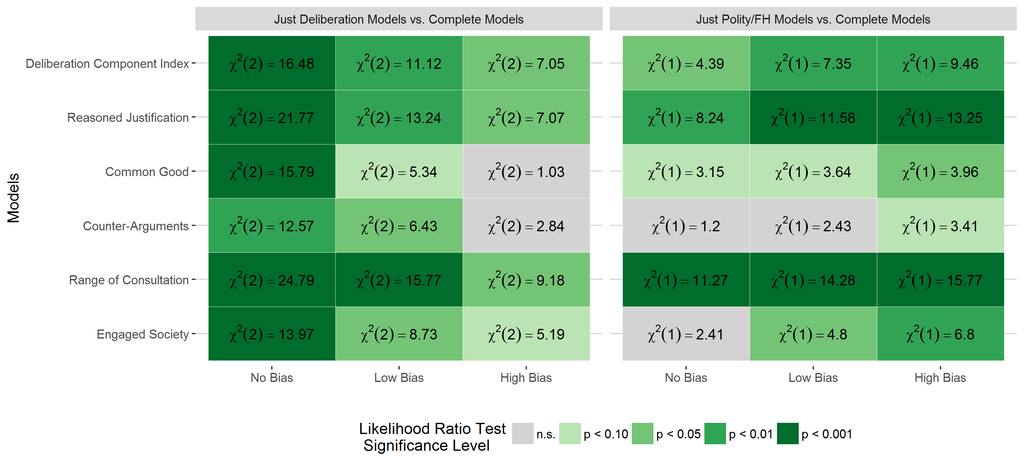

# Democracies Sample Models

Figure A3: Democracies Sample Models - Model Comparisons

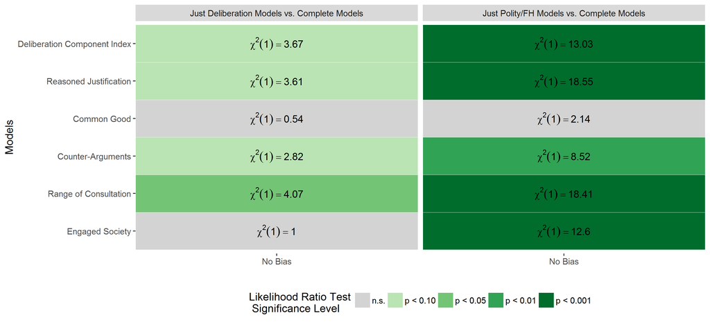

# Non-Democracies Sample Models

Figure A4: Non-Democracies Sample Models - Model Comparisons

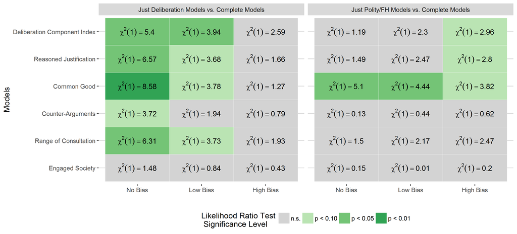

# Summary Table

| Variable | N | Mean | SD | Median | Min | Max | Skew | Kurtosis |
| --- | --- | --- | --- | --- | --- | --- | --- | --- |
| Financial Security | 316938 | 0.49 | 0.29 | 0.50 | 0.00 | 1.00 | -0.02 | -0.80 |
| Education | 316938 | 0.49 | 0.28 | 0.50 | 0.00 | 1.00 | 0.05 | -0.84 |
| Age | 316938 | 0.28 | 0.18 | 0.25 | 0.00 | 1.00 | 0.57 | -0.50 |
| Employment (0/1) | 316938 | 0.52 | 0.50 | 1.00 | 0.00 | 1.00 | -0.08 | -1.99 |
| Sex (Male/Female) | 316938 | 0.50 | 0.50 | 1.00 | 0.00 | 1.00 | -0.02 | -2.00 |
| Regime Support (No Bias) | 316938 | 0.48 | 0.26 | 0.49 | 0.00 | 1.00 | 0.04 | -0.69 |
| Regime Support (Low Bias) | 316938 | 0.47 | 0.26 | 0.48 | 0.00 | 1.00 | 0.02 | -0.67 |
| Regime Support (High Bias) | 316938 | 0.47 | 0.25 | 0.47 | 0.00 | 1.00 | 0.05 | -0.62 |
| DCI | 119 | 0.71 | 0.24 | 0.78 | 0.00 | 1.00 | -1.11 | 0.66 |
| Reasoned Justification | 119 | 0.55 | 0.21 | 0.56 | 0.00 | 1.00 | -0.18 | -0.38 |
| Common Good | 119 | 0.60 | 0.21 | 0.63 | 0.00 | 1.00 | -0.56 | -0.01 |
| Counter-Arguments | 119 | 0.59 | 0.22 | 0.62 | 0.00 | 1.00 | -0.53 | -0.23 |
| Range of Consultation | 119 | 0.49 | 0.19 | 0.50 | 0.00 | 1.00 | -0.22 | 0.00 |
| Engaged Society | 119 | 0.55 | 0.21 | 0.59 | 0.00 | 1.00 | -0.53 | 0.12 |
| Polity/FH | 119 | 0.68 | 0.30 | 0.78 | 0.00 | 1.00 | -0.73 | -0.74 |
| Life Expectancy | 119 | 0.65 | 0.26 | 0.74 | 0.00 | 1.00 | -0.72 | -0.61 |
| logged Population | 119 | 0.04 | 0.12 | 0.01 | 0.00 | 1.00 | 6.61 | 45.46 |
| logged GDP per Capita | 119 | 0.13 | 0.16 | 0.06 | 0.00 | 1.00 | 2.22 | 7.30 |
| Corruption | 119 | 0.65 | 0.27 | 0.74 | 0.00 | 1.00 | -0.83 | -0.41 |
| Urban Population Ratio | 119 | 0.02 | 0.09 | 0.02 | 0.00 | 1.00 | 10.54 | 110.75 |
| Democracy (0/1) | 119 | 0.54 | 0.50 | 1.00 | 0.00 | 1.00 | -0.15 | -1.99 |
| Anocracy (0/1) | 119 | 0.39 | 0.49 | 0.00 | 0.00 | 1.00 | 0.42 | -1.84 |
| Autocracy (0/1) | 119 | 0.07 | 0.25 | 0.00 | 0.00 | 1.00 | 3.41 | 9.73 |

# Country List

| Country | ISO Code | Nr. |
| --- | --- | --- |
| Albania | ALB | 1 |
| Algeria | DZA | 2 |
| Argentina | ARG | 3 |
| Armenia | ARM | 4 |
| Australia | AUS | 5 |
| Azerbaijan | AZE | 6 |
| Belarus | BLR | 7 |
| Belgium | BEL | 8 |
| Benin | BEN | 9 |
| Bolivia | BOL | 10 |
| Botswana | BWA | 11 |
| Brazil | BRA | 12 |
| Bulgaria | BGR | 13 |
| Burkina Faso | BFA | 14 |
| Burundi | BDI | 15 |
| Cambodia | KHM | 16 |
| Cameroon | CMR | 17 |
| Canada | CAN | 18 |
| Cape Verde | CPV | 19 |
| Chile | CHL | 20 |
| China | CHN | 21 |
| Colombia | COL | 22 |
| Costa Rica | CRI | 23 |
| Côte d’Ivoire | CIV | 24 |
| Cyprus | CYP | 25 |
| Czechia | CZE | 26 |
| Denmark | DNK | 27 |
| Dominican Republic | DOM | 28 |
| Ecuador | ECU | 29 |
| El Salvador | SLV | 30 |

[output cut: 89 more lines]

# Operationalization Regime Support

| Survey and Questions | Support Object | Answers | Item Code |
| --- | --- | --- | --- |
| Afrobarometer Round 5/6 |  |  |  |
| How much do you trust each of the following, or haven’t you heard enough about them to say: | ... the President/Prime Minister ... Parliament ... the Police ... courts of law | not at all (0) just a little (1) somewhat (2) a lot (3) | Q59A/Q52A Q59B/Q52B Q59H/Q52H Q59J/Q52J |
| AmericasBarometer |  |  |  |
| To what extent do you trust… | ... the President/Prime Minister? ... the National Congress? ... the National Police? ... the justice system? | not at all (1) - a lot (7) | B21A B13 B18 B10A |
| Asian Barometer Wave 3/4 |  |  |  |
| I’m going to name a number of institutions. For each one, please tell me how much trust do you have in them? | ... the National Government ... Parliament ... the Police ... the courts | a great deal (1) quite a lot (2) not very much (3) none at all (4) | q9 q11 q14 q8 |
| Using this card, please tell me on a score of 0-10 how much you, personally trust each of the institutions I read out. 0 means you do not trust, an institution at all, and 10 means you have complete t… | ... politicians? ... [country]'s parliament? ... the police? ... the legal system? | No trust at all (0) - Complete trust (10) | trstplt trstprl trstplc trstlgl |
| Latinobarómetro 2013/2015 |  |  |  |
| Please look at this card and tell me how much trust you have in each of the following groups/institutions. | ... the National Government ... National Congress/Parliament ... Police ... Judiciary | a lot (1) some (2) a little(3) none (4) | P26STGBS.B/P16ST.G P26STGBS.C/P16ST.F Q28STGBS.B/P16TGB.B P26STGBS.E/P16ST.H |
| World Values Survey Wave 6 |  |  |  |
| I'm going to name a number of organizations. For each one, could you tell me how much confidence you have in them: | ... the Government [in capital] ... Parliament ... the Police ... the Courts | a great deal (1) quite a lot (2) not very much (3) none at all (4) | V115 |

# Complete Sample: Statistical models A1.1 to F1.3

Table A8: Complete Sample: Statistical models A1.1 to F1.3

|  | DCI |  |  | Reasoned Justification |  |  | Common Good |  |  | Counter-Arguments |  |  | Range of Consultation |  |  | Engaged Society |  |  |  |
| --- | --- | --- | --- | --- | --- | --- | --- | --- | --- | --- | --- | --- | --- | --- | --- | --- | --- | --- | --- |
|  | Model A1.1 No Bias | Model A1.2 Low Bias | Model A1.3 High Bias | Model B1.1 No Bias | Model B1.2 Low Bias | Model B1.3 High Bias | Model C1.1 No Bias | Model C1.2 Low Bias | Model C1.3 High Bias | Model D1.1 No Bias | Model D1.2 Low Bias | Model D1.3 High Bias | Model E1.1 No Bias | Model E1.2 Low Bias | Model E1.3 High Bias | Model F1.1 No Bias | Model F1.2 Low Bias | Model F1.3 High Bias |  |
| (Intercept) | **.87***** | **.79***** | **.74***** | **.82***** | **.75***** | **.71***** | **.79***** | **.77***** | **.75***** | **.85***** | **.79***** | **.75***** | **.83***** | **.76***** | **.71***** | **.84***** | **.78***** | **.74***** |  |
|  | (.07) | (.06) | (.06) | (.07) | (.06) | (.06) | (.07) | (.07) | (.06) | (.07) | (.06) | (.06) | (.07) | (.07) | (.06) | (.06) | (.06) | (.06) |  |
| **Individual-Level Control Variables** |  |  |  |  |  |  |  |  |  |  |  |  |  |  |  |  |  |  |  |
| income | **.11***** | **.11***** | **.11***** | **.11***** | **.11***** | **.11***** | **.11***** | **.11***** | **.11***** | **.11***** | **.11***** | **.11***** | **.11***** | **.11***** | **.11***** | **.11***** | **.11***** | **.11***** |  |
|  | (.00) | (.00) | (.00) | (.00) | (.00) | (.00) | (.00) | (.00) | (.00) | (.00) | (.00) | (.00) | (.00) | (.00) | (.00) | (.00) | (.00) | (.00) |  |
| educ | **-.04***** | **-.04***** | **-.04***** | **-.04***** | **-.04***** | **-.04***** | **-.04***** | **-.04***** | **-.04***** | **-.04***** | **-.04***** | **-.04***** | **-.04***** | **-.04***** | **-.04***** | **-.04***** | **-.04***** | **-.04***** |  |
|  | (.00) | (.00) | (.00) | (.00) | (.00) | (.00) | (.00) | (.00) | (.00) | (.00) | (.00) | (.00) | (.00) | (.00) | (.00) | (.00) | (.00) | (.00) |  |
| work | **-.01***** | **-.01***** | **-.01***** | **-.01***** | **-.01***** | **-.01***** | **-.01***** | **-.01***** | **-.01***** | **-.01***** | **-.01***** | **-.01***** | **-.01***** | **-.01***** | **-.01***** | **-.01***** | **-.01***** | **-.01***** |  |
|  | (.00) | (.00) | (.00) | (.00) | (.00) | (.00) | (.00) | (.00) | (.00) | (.00) | (.00) | (.00) | (.00) | (.00) | (.00) | (.00) | (.00) | (.00) |  |
| age | **.04***** | **.04***** | **.04***** | **.04***** | **.04***** | **.04***** | **.04***** | **.04***** | **.04***** | **.04***** | **.04***** | **.04***** | **.04***** | **.04***** | **.04***** | **.04***** | **.04***** | **.04***** |  |
|  | (.00) | (.00) | (.00) | (.00) | (.00) | (.00) | (.00) | (.00) | (.00) | (.00) | (.00) | (.00) | (.00) | (.00) | (.00) | (.00) | (.00) | (.00) |  |
| sex | **.00***** | **.00***** | **.00***** | **.00***** | **.00***** | **.00***** | **.00***** | **.00***** | **.00***** | **.00***** | **.00***** | **.00***** | **.00***** | **.00***** | **.00***** | **.00***** | **.00***** | **.00***** |  |
|  | (.00) | (.00) | (.00) | (.00) | (.00) | (.00) | (.00) | (.00) | (.00) | (.00) | (.00) | (.00) | (.00) | (.00) | (.00) | (.00) | (.00) | (.00) |  |
| **Country-Level Control Variables** |  |  |  |  |  |  |  |  |  |  |  |  |  |  |  |  |  |  |  |
| pop10 | **.29**** | **.24*** | **.18**<sup>^</sup> | **.29**** | **.23*** | **.17**<sup>^</sup> | **.28**** | **.23*** | **.19**<sup>^</sup> | **.27**** | **.23*** | **.19*** | **.28**** | **.23*** | **.18**<sup>^</sup> | **.28**** | **.23*** | **.18*** |  |
|  | (.10) | (.10) | (.09) | (.11) | (.10) | (.09) | (.11) | (.10) | (.10) | (.10) | (.10) | (.09) | (.10) | (.10) | (.09) | (.10) | (.10) | (.09) |  |
| gdp10 | .16 | .10 | .06 | .20 | .11 | .06 | .19 | .11 | .06 | .18 | .10 | .06 | .18 | .11 | .07 | .16 | .10 | .06 |  |
|  | (.13) | (.12) | (.12) | (.14) | (.12) | (.12) | (.14) | (.12) | (.12) | (.13) | (.12) | (.12) | (.14) | (.12) | (.12) | (.13) | (.12) | (.12) |  |
| lifeexp10 | **-.27***** | **-.25***** | **-.24***** | **-.28***** | **-.26***** | **-.25***** | **-.29***** | **-.26***** | **-.24***** | **-.28***** | **-.26***** | **-.24***** | **-.28***** | **-.26***** | **-.25***** | **-.27***** | **-.25***** | **-.25***** |  |
|  | (.05) | (.04) | (.04) | (.05) | (.04) | (.04) | (.05) | (.04) | (.04) | (.05) | (.04) | (.04) | (.05) | (.04) | (.04) | (.05) | (.04) | (.04) |  |
| corrupt10 | **-.26***** | **-.25***** | **-.24***** | **-.24***** | **-.23***** | **-.22***** | **-.23***** | **-.24***** | **-.24***** | **-.25***** | **-.25***** | **-.24***** | **-.25***** | **-.23***** | **-.22***** | **-.25***** | **-.24***** | **-.24***** |  |
|  | (.06) | (.06) | (.05) | (.06) | (.06) | (.05) | (.06) | (.06) | (.05) | (.06) | (.05) | (.05) | (.06) | (.06) | (.06) | (.06) | (.05) | (.05) |  |
| urbanratio10 | -.03 | -.05 | -.06 | .02 | -.02 | -.04 | .03 | -.03 | -.06 | -.01 | -.04 | -.06 | .01 | -.03 | -.05 | -.02 | -.04 | -.06 |  |
|  | (.10) | (.10) | (.10) | (.10) | (.10) | (.09) | (.10) | (.10) | (.09) | (.10) | (.10) | (.09) | (.10) | (.10) | (.09) | (.10) | (.10) | (.09) |  |
| **Dataset Control Dummies** |  |  |  |  |  |  |  |  |  |  |  |  |  |  |  |  |  |  |  |
| afro | -.00 | -.00 | -.00 | -.00 | -.00 | -.00 | -.00 | -.00 | -.00 | -.00 | -.00 | -.00 | -.00 | -.00 | -.00 | -.00 | -.00 | -.00 |  |
|  | (.00) | (.00) | (.00) | (.00) | (.00) | (.00) | (.00) | (.00) | (.00) | (.00) | (.00) | (.00) | (.00) | (.00) | (.00) | (.00) | (.00) | (.00) |  |
| latino | **-.03***** | **-.03***** | **-.03***** | **-.03***** | **-.03***** | **-.03***** | **-.03***** | **-.03***** | **-.03***** | **-.03***** | **-.03***** | **-.03***** | **-.03***** | **-.03***** | **-.03***** | **-.03***** | **-.03***** | **-.03***** |  |
|  | (.00) | (.00) | (.00) | (.00) | (.00) | (.00) | (.00) | (.00) | (.00) | (.00) | (.00) | (.00) | (.00) | (.00) | (.00) | (.00) | (.00) | (.00) |  |
| americas | **.07***** | **.07***** | **.07***** | **.07***** | **.07***** | **.07***** | **.07***** | **.07***** | **.07***** | **.07***** | **.07***** | **.07***** | **.07***** | **.07***** | **.07***** | **.07***** | **.07***** | **.07***** |  |
|  | (.00) | (.00) | (.00) | (.00) | (.00) | (.00) | (.00) | (.00) | (.00) | (.00) | (.00) | (.00) | (.00) | (.00) | (.00) | (.00) | (.00) | (.00) |  |
| asian | **-.05***** | **-.05***** | **-.05***** | **-.05***** | **-.05***** | **-.05***** | **-.05***** | **-.05***** | **-.05***** | **-.05***** | **-.05***** | **-.05***** | **-.05***** | **-.05***** | **-.05***** | **-.05***** | **-.05***** | **-.05***** |  |
|  | (.00) | (.00) | (.00) | (.00) | (.00) | (.00) | (.00) | (.00) | (.00) | (.00) | (.00) | (.00) | (.00) | (.00) | (.00) | (.00) | (.00) | (.00) |  |
| ESS | **-.07***** | **-.07***** | **-.07***** | **-.07***** | **-.07***** | **-.07***** | **-.07***** | **-.07***** | **-.07***** | **-.07***** | **-.07***** | **-.07***** | **-.07***** | **-.07***** | **-.07***** | **-.07***** | **-.07***** | **-.07***** |  |
|  | (.00) | (.00) | (.00) | (.00) | (.00) | (.00) | (.00) | (.00) | (.00) | (.00) | (.00) | (.00) | (.00) | (.00) | (.00) | (.00) | (.00) | (.00) |  |
| **DCI & Subcomponents** |  |  |  |  |  |  |  |  |  |  |  |  |  |  |  |  |  |  |  |
| delib10 | **-.12**** | -.05 | .01 |  |  |  |  |  |  |  |  |  |  |  |  |  |  |  |  |
|  | (.04) | (.04) | (.04) |  |  |  |  |  |  |  |  |  |  |  |  |  |  |  |  |
| reason10 |  |  |  | -.08 | -.00 | .05 |  |  |  |  |  |  |  |  |  |  |  |  |  |
|  |  |  |  | (.06) | (.05) | (.05) |  |  |  |  |  |  |  |  |  |  |  |  |  |
| common10 |  |  |  |  |  |  | -.04 | -.02 | .00 |  |  |  |  |  |  |  |  |  |  |
|  |  |  |  |  |  |  | (.05) | (.05) | (.05) |  |  |  |  |  |  |  |  |  |  |
| countr10 |  |  |  |  |  |  |  |  |  | **-.12**** | -.05 | -.00 |  |  |  |  |  |  |  |
|  |  |  |  |  |  |  |  |  |  | (.05) | (.04) | (.04) |  |  |  |  |  |  |  |
| consult10 |  |  |  |  |  |  |  |  |  |  |  |  | -.09 | -.01 | .05 |  |  |  |  |
|  |  |  |  |  |  |  |  |  |  |  |  |  | (.06) | (.05) | (.05) |  |  |  |  |
| engage10 |  |  |  |  |  |  |  |  |  |  |  |  |  |  |  | **-.13**** | -.05 | .01 |  |
|  |  |  |  |  |  |  |  |  |  |  |  |  |  |  |  | (.05) | (.05) | (.05) |  |
| AIC | $26093.27$ | $15081.26$ | $6532.22$ | $26098.07$ | $15082.09$ | $6530.63$ | $26099.51$ | $15082.19$ | $6531.97$ | $26093.66$ | $15080.91$ | $6532.12$ | $26097.55$ | $15082.00$ | $6530.90$ | $26093.56$ | $15081.17$ | $6531.89$ |  |
| BIC | $26295.93$ | $15283.92$ | $6734.88$ | $26300.73$ | $15284.76$ | $6733.30$ | $26302.17$ | $15284.85$ | $6734.64$ | $26296.32$ | $15283.57$ | $6734.79$ | $26300.21$ | $15284.66$ | $6733.56$ | $26296.22$ | $15283.83$ | $6734.55$ |  |
| Log Likelihood | $-13027.63$ | $-7521.63$ | $-3247.11$ | $-13030.03$ | $-7522.05$ | $-3246.32$ | $-13030.75$ | $-7522.10$ | $-3246.99$ | $-13027.83$ | $-7521.45$ | $-3247.06$ | $-13029.77$ | $-7522.00$ | $-3246.45$ | $-13027.78$ | $-7521.58$ | $-3246.95$ |  |
| Num. obs. | $316938$ | $316938$ | $316938$ | $316938$ | $316938$ | $316938$ | $316938$ | $316938$ | $316938$ | $316938$ | $316938$ | $316938$ | $316938$ | $316938$ | $316938$ | $316938$ | $316938$ | $316938$ |  |
| Num. groups: cntry | $119$ | $119$ | $119$ | $119$ | $119$ | $119$ | $119$ | $119$ | $119$ | $119$ | $119$ | $119$ | $119$ | $119$ | $119$ | $119$ | $119$ | $119$ |  |
| Var: cntry (Intercept) | $0.01$ | $0.01$ | $0.01$ | $0.01$ | $0.01$ | $0.01$ | $0.01$ | $0.01$ | $0.01$ | $0.01$ | $0.01$ | $0.01$ | $0.01$ | $0.01$ | $0.01$ | $0.01$ | $0.01$ | $0.01$ |  |
| Var: Residual | $0.02$ | $0.02$ | $0.02$ | $0.02$ | $0.02$ | $0.02$ | $0.02$ | $0.02$ | $0.02$ | $0.02$ | $0.02$ | $0.02$ | $0.02$ | $0.02$ | $0.02$ | $0.02$ | $0.02$ | $0.02$ |  |
| ***p < 0.001, **p < 0.01, *p < 0.05, <sup>^</sup>p < 0.1 |  |  |  |  |  |  |  |  |  |  |  |  |  |  |  |  |  |  |  |

# Complete Sample (including Polity/FH dummies): Statistical models A1.4 to F1.6

Table A9: Complete Sample (including Polity/FH dummies): Statistical models A1.4 to F1.6

|  | DCI |  |  | Reasoned Justification |  |  | Common Good |  |  | Counter-Arguments |  |  | Range of Consultation |  |  | Engaged Society |  |  |  |
| --- | --- | --- | --- | --- | --- | --- | --- | --- | --- | --- | --- | --- | --- | --- | --- | --- | --- | --- | --- |
|  | Model A1.4 No Bias | Model A1.5 Low Bias | Model A1.6 High Bias | Model B1.4 No Bias | Model B1.5 Low Bias | Model B1.6 High Bias | Model C1.4 No Bias | Model C1.5 Low Bias | Model C1.6 High Bias | Model D1.4 No Bias | Model D1.5 Low Bias | Model D1.6 High Bias | Model E1.4 No Bias | Model E1.5 Low Bias | Model E1.6 High Bias | Model F1.4 No Bias | Model F1.5 Low Bias | Model F1.6 High Bias |  |
| (Intercept) | **.75***** | **.70***** | **.67***** | **.73***** | **.69***** | **.66***** | **.81***** | **.78***** | **.75***** | **.78***** | **.74***** | **.71***** | **.71***** | **.67***** | **.65***** | **.76***** | **.72***** | **.69***** |  |
|  | (.07) | (.06) | (.06) | (.06) | (.06) | (.06) | (.06) | (.06) | (.06) | (.06) | (.06) | (.06) | (.07) | (.06) | (.06) | (.06) | (.06) | (.06) |  |
| **Individual-Level Control Variables** |  |  |  |  |  |  |  |  |  |  |  |  |  |  |  |  |  |  |  |
| income | **.11***** | **.11***** | **.11***** | **.11***** | **.11***** | **.11***** | **.11***** | **.11***** | **.11***** | **.11***** | **.11***** | **.11***** | **.11***** | **.11***** | **.11***** | **.11***** | **.11***** | **.11***** |  |
|  | (.00) | (.00) | (.00) | (.00) | (.00) | (.00) | (.00) | (.00) | (.00) | (.00) | (.00) | (.00) | (.00) | (.00) | (.00) | (.00) | (.00) | (.00) |  |
| educ | **-.04***** | **-.04***** | **-.04***** | **-.04***** | **-.04***** | **-.04***** | **-.04***** | **-.04***** | **-.04***** | **-.04***** | **-.04***** | **-.04***** | **-.04***** | **-.04***** | **-.04***** | **-.04***** | **-.04***** | **-.04***** |  |
|  | (.00) | (.00) | (.00) | (.00) | (.00) | (.00) | (.00) | (.00) | (.00) | (.00) | (.00) | (.00) | (.00) | (.00) | (.00) | (.00) | (.00) | (.00) |  |
| work | **-.01***** | **-.01***** | **-.01***** | **-.01***** | **-.01***** | **-.01***** | **-.01***** | **-.01***** | **-.01***** | **-.01***** | **-.01***** | **-.01***** | **-.01***** | **-.01***** | **-.01***** | **-.01***** | **-.01***** | **-.01***** |  |
|  | (.00) | (.00) | (.00) | (.00) | (.00) | (.00) | (.00) | (.00) | (.00) | (.00) | (.00) | (.00) | (.00) | (.00) | (.00) | (.00) | (.00) | (.00) |  |
| age | **.04***** | **.04***** | **.04***** | **.04***** | **.04***** | **.04***** | **.04***** | **.04***** | **.04***** | **.04***** | **.04***** | **.04***** | **.04***** | **.04***** | **.04***** | **.04***** | **.04***** | **.04***** |  |
|  | (.00) | (.00) | (.00) | (.00) | (.00) | (.00) | (.00) | (.00) | (.00) | (.00) | (.00) | (.00) | (.00) | (.00) | (.00) | (.00) | (.00) | (.00) |  |
| sex | **.00***** | **.00***** | **.00***** | **.00***** | **.00***** | **.00***** | **.00***** | **.00***** | **.00***** | **.00***** | **.00***** | **.00***** | **.00***** | **.00***** | **.00***** | **.00***** | **.00***** | **.00***** |  |
|  | (.00) | (.00) | (.00) | (.00) | (.00) | (.00) | (.00) | (.00) | (.00) | (.00) | (.00) | (.00) | (.00) | (.00) | (.00) | (.00) | (.00) | (.00) |  |
| **Country-Level Control Variables** |  |  |  |  |  |  |  |  |  |  |  |  |  |  |  |  |  |  |  |
| polity_demdummy | **-.05**<sup>^</sup> | -.03 | -.02 | **-.05*** | **-.04**<sup>^</sup> | -.02 | -.03 | -.01 | .00 | -.04 | -.03 | -.01 | **-.05*** | **-.04**<sup>^</sup> | -.02 | **-.04**<sup>^</sup> | -.03 | -.02 |  |
|  | (.02) | (.02) | (.02) | (.02) | (.02) | (.02) | (.02) | (.02) | (.02) | (.02) | (.02) | (.02) | (.02) | (.02) | (.02) | (.02) | (.02) | (.02) |  |
| polity_autodummy | **.21***** | **.17***** | **.14**** | **.21***** | **.16***** | **.13**** | **.18***** | **.13***** | **.09*** | **.19***** | **.15***** | **.11**** | **.22***** | **.17***** | **.14***** | **.21***** | **.17***** | **.14**** |  |
|  | (.04) | (.04) | (.04) | (.04) | (.04) | (.04) | (.04) | (.04) | (.04) | (.04) | (.04) | (.04) | (.04) | (.04) | (.04) | (.04) | (.04) | (.04) |  |
| pop10 | .11 | .09 | .06 | .09 | .08 | .06 | .15 | .14 | .12 | .13 | .12 | .11 | .09 | .08 | .06 | .12 | .10 | .08 |  |
|  | (.10) | (.10) | (.10) | (.10) | (.10) | (.10) | (.10) | (.10) | (.10) | (.10) | (.09) | (.10) | (.10) | (.09) | (.10) | (.10) | (.10) | (.10) |  |
| gdp10 | .05 | .01 | -.02 | .03 | -.02 | -.05 | .05 | .01 | -.01 | .05 | .01 | -.02 | .05 | .01 | -.02 | .05 | .01 | -.02 |  |
|  | (.12) | (.12) | (.12) | (.12) | (.12) | (.12) | (.13) | (.12) | (.12) | (.12) | (.12) | (.12) | (.12) | (.12) | (.12) | (.12) | (.12) | (.12) |  |
| lifeexp10 | **-.24***** | **-.23***** | **-.23***** | **-.24***** | **-.23***** | **-.23***** | **-.24***** | **-.23***** | **-.23***** | **-.24***** | **-.23***** | **-.22***** | **-.23***** | **-.22***** | **-.22***** | **-.24***** | **-.24***** | **-.23***** |  |
|  | (.04) | (.04) | (.04) | (.04) | (.04) | (.04) | (.04) | (.04) | (.04) | (.04) | (.04) | (.04) | (.04) | (.04) | (.04) | (.04) | (.04) | (.04) |  |
| corrupt10 | **-.26***** | **-.25***** | **-.24***** | **-.25***** | **-.24***** | **-.23***** | **-.28***** | **-.27***** | **-.26***** | **-.27***** | **-.26***** | **-.26***** | **-.24***** | **-.23***** | **-.22***** | **-.27***** | **-.26***** | **-.25***** |  |
|  | (.05) | (.05) | (.05) | (.05) | (.05) | (.05) | (.06) | (.05) | (.05) | (.05) | (.05) | (.05) | (.06) | (.05) | (.05) | (.05) | (.05) | (.05) |  |
| urbanratio10 | -.13 | -.13 | -.13 | -.13 | -.14 | -.13 | -.14 | -.15 | -.14 | -.14 | -.14 | -.14 | -.14 | -.14 | -.14 | -.13 | -.14 | -.14 |  |
|  | (.10) | (.09) | (.10) | (.10) | (.09) | (.09) | (.10) | (.10) | (.10) | (.10) | (.10) | (.10) | (.10) | (.09) | (.09) | (.10) | (.09) | (.09) |  |
| **Dataset Control Dummies** |  |  |  |  |  |  |  |  |  |  |  |  |  |  |  |  |  |  |  |
| afro | -.00 | -.00 | -.00 | -.00 | -.00 | -.00 | -.00 | -.00 | -.00 | -.00 | -.00 | -.00 | -.00 | -.00 | -.00 | -.00 | -.00 | -.00 |  |
|  | (.00) | (.00) | (.00) | (.00) | (.00) | (.00) | (.00) | (.00) | (.00) | (.00) | (.00) | (.00) | (.00) | (.00) | (.00) | (.00) | (.00) | (.00) |  |
| latino | **-.03***** | **-.03***** | **-.03***** | **-.03***** | **-.03***** | **-.03***** | **-.03***** | **-.03***** | **-.03***** | **-.03***** | **-.03***** | **-.03***** | **-.03***** | **-.03***** | **-.03***** | **-.03***** | **-.03***** | **-.03***** |  |
|  | (.00) | (.00) | (.00) | (.00) | (.00) | (.00) | (.00) | (.00) | (.00) | (.00) | (.00) | (.00) | (.00) | (.00) | (.00) | (.00) | (.00) | (.00) |  |
| americas | **.07***** | **.07***** | **.07***** | **.07***** | **.07***** | **.07***** | **.07***** | **.07***** | **.07***** | **.07***** | **.07***** | **.07***** | **.07***** | **.07***** | **.07***** | **.07***** | **.07***** | **.07***** |  |
|  | (.00) | (.00) | (.00) | (.00) | (.00) | (.00) | (.00) | (.00) | (.00) | (.00) | (.00) | (.00) | (.00) | (.00) | (.00) | (.00) | (.00) | (.00) |  |
| asian | **-.05***** | **-.05***** | **-.05***** | **-.05***** | **-.05***** | **-.05***** | **-.05***** | **-.05***** | **-.05***** | **-.05***** | **-.05***** | **-.05***** | **-.05***** | **-.05***** | **-.05***** | **-.05***** | **-.05***** | **-.05***** |  |
|  | (.00) | (.00) | (.00) | (.00) | (.00) | (.00) | (.00) | (.00) | (.00) | (.00) | (.00) | (.00) | (.00) | (.00) | (.00) | (.00) | (.00) | (.00) |  |
| ESS | **-.07***** | **-.07***** | **-.07***** | **-.07***** | **-.07***** | **-.07***** | **-.07***** | **-.07***** | **-.07***** | **-.07***** | **-.07***** | **-.07***** | **-.07***** | **-.07***** | **-.07***** | **-.07***** | **-.07***** | **-.07***** |  |
|  | (.00) | (.00) | (.00) | (.00) | (.00) | (.00) | (.00) | (.00) | (.00) | (.00) | (.00) | (.00) | (.00) | (.00) | (.00) | (.00) | (.00) | (.00) |  |
| **DCI & Subcomponents** |  |  |  |  |  |  |  |  |  |  |  |  |  |  |  |  |  |  |  |
| delib10 | .06 | **.09**<sup>^</sup> | **.12*** |  |  |  |  |  |  |  |  |  |  |  |  |  |  |  |  |
|  | (.06) | (.05) | (.05) |  |  |  |  |  |  |  |  |  |  |  |  |  |  |  |  |
| reason10 |  |  |  | **.11**<sup>^</sup> | **.14*** | **.16*** |  |  |  |  |  |  |  |  |  |  |  |  |  |
|  |  |  |  | (.06) | (.06) | (.06) |  |  |  |  |  |  |  |  |  |  |  |  |  |
| common10 |  |  |  |  |  |  | -.01 | -.00 | .01 |  |  |  |  |  |  |  |  |  |  |
|  |  |  |  |  |  |  | (.05) | (.05) | (.05) |  |  |  |  |  |  |  |  |  |  |
| countr10 |  |  |  |  |  |  |  |  |  | .03 | .05 | .07 |  |  |  |  |  |  |  |
|  |  |  |  |  |  |  |  |  |  | (.06) | (.05) | (.05) |  |  |  |  |  |  |  |
| consult10 |  |  |  |  |  |  |  |  |  |  |  |  | **.13*** | **.16*** | **.18**** |  |  |  |  |
|  |  |  |  |  |  |  |  |  |  |  |  |  | (.07) | (.06) | (.06) |  |  |  |  |
| engage10 |  |  |  |  |  |  |  |  |  |  |  |  |  |  |  | .06 | **.10**<sup>^</sup> | **.13*** |  |
|  |  |  |  |  |  |  |  |  |  |  |  |  |  |  |  | (.06) | (.06) | (.06) |  |
| AIC | $26084.90$ | $15079.34$ | $6535.54$ | $26082.83$ | $15076.84$ | $6533.33$ | $26086.34$ | $15082.63$ | $6540.39$ | $26085.79$ | $15081.29$ | $6538.34$ | $26081.71$ | $15075.96$ | $6532.59$ | $26084.79$ | $15079.21$ | $6535.29$ |  |
| BIC | $26308.90$ | $15303.33$ | $6759.54$ | $26306.83$ | $15300.84$ | $6757.32$ | $26310.33$ | $15306.62$ | $6764.38$ | $26309.78$ | $15305.29$ | $6762.33$ | $26305.71$ | $15299.96$ | $6756.58$ | $26308.79$ | $15303.21$ | $6759.29$ |  |
| Log Likelihood | $-13021.45$ | $-7518.67$ | $-3246.77$ | $-13020.42$ | $-7517.42$ | $-3245.66$ | $-13022.17$ | $-7520.31$ | $-3249.19$ | $-13021.89$ | $-7519.65$ | $-3248.17$ | $-13019.86$ | $-7516.98$ | $-3245.29$ | $-13021.40$ | $-7518.61$ | $-3246.65$ |  |
| Num. obs. | $316938$ | $316938$ | $316938$ | $316938$ | $316938$ | $316938$ | $316938$ | $316938$ | $316938$ | $316938$ | $316938$ | $316938$ | $316938$ | $316938$ | $316938$ | $316938$ | $316938$ | $316938$ |  |
| Num. groups: cntry | $119$ | $119$ | $119$ | $119$ | $119$ | $119$ | $119$ | $119$ | $119$ | $119$ | $119$ | $119$ | $119$ | $119$ | $119$ | $119$ | $119$ | $119$ |  |
| Var: cntry (Intercept) | $0.01$ | $0.01$ | $0.01$ | $0.01$ | $0.01$ | $0.01$ | $0.01$ | $0.01$ | $0.01$ | $0.01$ | $0.01$ | $0.01$ | $0.01$ | $0.01$ | $0.01$ | $0.01$ | $0.01$ | $0.01$ |  |
| Var: Residual | $0.02$ | $0.02$ | $0.02$ | $0.02$ | $0.02$ | $0.02$ | $0.02$ | $0.02$ | $0.02$ | $0.02$ | $0.02$ | $0.02$ | $0.02$ | $0.02$ | $0.02$ | $0.02$ | $0.02$ | $0.02$ |  |
| ***p < 0.001, **p < 0.01, *p < 0.05, <sup>^</sup>p < 0.1 |  |  |  |  |  |  |  |  |  |  |  |  |  |  |  |  |  |  |  |

# Democracy Sample: Statistical models A2.1 to F2.2

Table A10: Democracy Sample: Statistical models A2.1 to F2.2

|  | DCI |  | Reasoned Justification |  | Common Good |  | Counter-Arguments |  | Range of Consultation |  | Engaged Society |  |  |
| --- | --- | --- | --- | --- | --- | --- | --- | --- | --- | --- | --- | --- | --- |
|  | *Model A2.1* | Model A2.2 (Polity/FH) | *Model B2.1* | Model B2.2 (Polity/FH) | *Model C2.1* | Model C2.2 (Polity/FH) | *Model D2.1* | Model D2.2 (Polity/FH) | *Model E2.1* | Model E2.2 (Polity/FH) | *Model F2.1* | Model F2.2 (Polity/FH) |  |
| (Intercept) | **.79***** | **.83***** | **.78***** | **.82***** | **.87***** | **.91***** | **.83***** | **.89***** | **.79***** | **.84***** | **.81***** | **.87***** |  |
|  | (.08) | (.07) | (.08) | (.07) | (.07) | (.07) | (.07) | (.06) | (.07) | (.07) | (.07) | (.06) |  |
| **Individual-Level Control Variables** |  |  |  |  |  |  |  |  |  |  |  |  |  |
| income | **.10***** | **.10***** | **.10***** | **.10***** | **.10***** | **.10***** | **.10***** | **.10***** | **.10***** | **.10***** | **.10***** | **.10***** |  |
|  | (.00) | (.00) | (.00) | (.00) | (.00) | (.00) | (.00) | (.00) | (.00) | (.00) | (.00) | (.00) |  |
| educ | .00 | .00 | .00 | .00 | .00 | .00 | .00 | .00 | .00 | .00 | .00 | .00 |  |
|  | (.00) | (.00) | (.00) | (.00) | (.00) | (.00) | (.00) | (.00) | (.00) | (.00) | (.00) | (.00) |  |
| work | **-.01***** | **-.01***** | **-.01***** | **-.01***** | **-.01***** | **-.01***** | **-.01***** | **-.01***** | **-.01***** | **-.01***** | **-.01***** | **-.01***** |  |
|  | (.00) | (.00) | (.00) | (.00) | (.00) | (.00) | (.00) | (.00) | (.00) | (.00) | (.00) | (.00) |  |
| age | **.03***** | **.03***** | **.03***** | **.03***** | **.03***** | **.03***** | **.03***** | **.03***** | **.03***** | **.03***** | **.03***** | **.03***** |  |
|  | (.00) | (.00) | (.00) | (.00) | (.00) | (.00) | (.00) | (.00) | (.00) | (.00) | (.00) | (.00) |  |
| sex | **.00***** | **.00***** | **.00***** | **.00***** | **.00***** | **.00***** | **.00***** | **.00***** | **.00***** | **.00***** | **.00***** | **.00***** |  |
|  | (.00) | (.00) | (.00) | (.00) | (.00) | (.00) | (.00) | (.00) | (.00) | (.00) | (.00) | (.00) |  |
| **Country-Level Control Variables** |  |  |  |  |  |  |  |  |  |  |  |  |  |
| pop10 | .08 | .03 | .09 | .06 | .12 | .10 | .08 | .02 | .09 | .06 | .08 | .06 |  |
|  | (.10) | (.09) | (.10) | (.09) | (.10) | (.10) | (.10) | (.09) | (.10) | (.09) | (.09) | (.09) |  |
| gdp10 | -.05 | .03 | -.06 | .01 | -.05 | .01 | -.04 | .05 | -.04 | .03 | -.06 | -.00 |  |
|  | (.11) | (.10) | (.11) | (.10) | (.11) | (.11) | (.11) | (.10) | (.11) | (.10) | (.10) | (.10) |  |
| lifeexp10 | **-.31***** | **-.26***** | **-.33***** | **-.29***** | **-.31***** | **-.27***** | **-.32***** | **-.28***** | **-.31***** | **-.27***** | **-.31***** | **-.27***** |  |
|  | (.06) | (.06) | (.06) | (.06) | (.06) | (.06) | (.06) | (.06) | (.06) | (.06) | (.06) | (.06) |  |
| corrupt10 | **-.29***** | **-.34***** | **-.26***** | **-.31***** | **-.32***** | **-.37***** | **-.31***** | **-.38***** | **-.26***** | **-.31***** | **-.29***** | **-.35***** |  |
|  | (.06) | (.06) | (.07) | (.06) | (.07) | (.07) | (.06) | (.06) | (.07) | (.06) | (.06) | (.06) |  |
| urbanratio10 | -.05 | -.07 | -.02 | -.03 | -.04 | -.05 | -.04 | -.06 | -.04 | -.05 | -.04 | -.05 |  |
|  | (.06) | (.05) | (.06) | (.05) | (.06) | (.06) | (.06) | (.05) | (.06) | (.05) | (.06) | (.05) |  |
| polity10 |  | **-.14***** |  | **-.12**** |  | **-.10*** |  | **-.16***** |  | **-.13***** |  | **-.11**** |  |
|  |  | (.04) |  | (.04) |  | (.04) |  | (.04) |  | (.04) |  | (.04) |  |
| **Dataset Control Dummies** |  |  |  |  |  |  |  |  |  |  |  |  |  |
| afro | **-.02***** | **-.02***** | **-.02***** | **-.02**** | **-.02***** | **-.02**** | **-.02***** | **-.02**** | **-.02***** | **-.02***** | **-.02***** | **-.02**** |  |
|  | (.01) | (.01) | (.01) | (.01) | (.01) | (.01) | (.01) | (.01) | (.01) | (.01) | (.01) | (.01) |  |
| latino | **-.03***** | **-.04***** | **-.03***** | **-.04***** | **-.03***** | **-.04***** | **-.03***** | **-.04***** | **-.04***** | **-.04***** | **-.04***** | **-.04***** |  |
|  | (.00) | (.00) | (.00) | (.00) | (.00) | (.00) | (.00) | (.00) | (.00) | (.00) | (.00) | (.00) |  |
| americas | **.06***** | **.06***** | **.06***** | **.06***** | **.06***** | **.06***** | **.06***** | **.06***** | **.06***** | **.06***** | **.06***** | **.06***** |  |
|  | (.00) | (.00) | (.00) | (.00) | (.00) | (.00) | (.00) | (.00) | (.00) | (.00) | (.00) | (.00) |  |
| asian | **-.11***** | **-.11***** | **-.11***** | **-.11***** | **-.11***** | **-.11***** | **-.11***** | **-.11***** | **-.11***** | **-.11***** | **-.11***** | **-.11***** |  |
|  | (.00) | (.00) | (.00) | (.00) | (.00) | (.00) | (.00) | (.00) | (.00) | (.00) | (.00) | (.00) |  |
| ESS | **-.05***** | **-.05***** | **-.05***** | **-.05***** | **-.05***** | **-.05***** | **-.05***** | **-.05***** | **-.05***** | **-.05***** | **-.05***** | **-.05***** |  |
|  | (.00) | (.00) | (.00) | (.00) | (.00) | (.00) | (.00) | (.00) | (.00) | (.00) | (.00) | (.00) |  |
| **DCI & Subcomponents** |  |  |  |  |  |  |  |  |  |  |  |  |  |
| delib10 | **.10*** | **.16***** |  |  |  |  |  |  |  |  |  |  |  |
|  | (.05) | (.05) |  |  |  |  |  |  |  |  |  |  |  |
| reason10 |  |  | **.13*** | **.17**** |  |  |  |  |  |  |  |  |  |
|  |  |  | (.06) | (.06) |  |  |  |  |  |  |  |  |  |
| common10 |  |  |  |  | .02 | .04 |  |  |  |  |  |  |  |
|  |  |  |  |  | (.05) | (.05) |  |  |  |  |  |  |  |
| countr10 |  |  |  |  |  |  | **.09**<sup>^</sup> | **.16***** |  |  |  |  |  |
|  |  |  |  |  |  |  | (.04) | (.04) |  |  |  |  |  |
| consult10 |  |  |  |  |  |  |  |  | **.14*** | **.18***** |  |  |  |
|  |  |  |  |  |  |  |  |  | (.06) | (.05) |  |  |  |
| engage10 |  |  |  |  |  |  |  |  |  |  | **.13**** | **.14***** |  |
|  |  |  |  |  |  |  |  |  |  |  | (.04) | (.04) |  |
| AIC | $-10998.67$ | $-11003.78$ | $-11000.02$ | $-11002.63$ | $-10994.96$ | $-10994.40$ | $-10998.30$ | $-11005.65$ | $-11000.79$ | $-11005.02$ | $-11002.88$ | $-11004.40$ |  |
| BIC | $-10807.12$ | $-10802.15$ | $-10808.48$ | $-10801.00$ | $-10803.41$ | $-10792.78$ | $-10806.75$ | $-10804.02$ | $-10809.24$ | $-10803.40$ | $-10811.33$ | $-10802.77$ |  |
| Log Likelihood | $5518.33$ | $5521.89$ | $5519.01$ | $5521.32$ | $5516.48$ | $5517.20$ | $5518.15$ | $5522.82$ | $5519.39$ | $5522.51$ | $5520.44$ | $5522.20$ |  |
| Num. obs. | $176552$ | $176552$ | $176552$ | $176552$ | $176552$ | $176552$ | $176552$ | $176552$ | $176552$ | $176552$ | $176552$ | $176552$ |  |
| Num. groups: cntry | $64$ | $64$ | $64$ | $64$ | $64$ | $64$ | $64$ | $64$ | $64$ | $64$ | $64$ | $64$ |  |
| Var: cntry (Intercept) | $0.01$ | $0.00$ | $0.01$ | $0.00$ | $0.01$ | $0.01$ | $0.01$ | $0.00$ | $0.00$ | $0.00$ | $0.00$ | $0.00$ |  |
| Var: Residual | $0.01$ | $0.01$ | $0.01$ | $0.01$ | $0.01$ | $0.01$ | $0.01$ | $0.01$ | $0.01$ | $0.01$ | $0.01$ | $0.01$ |  |
| ***p < 0.001, **p < 0.01, *p < 0.05, <sup>^</sup>p < 0.1 |  |  |  |  |  |  |  |  |  |  |  |  |  |

# Non-Democracies Sample: Statistical models A3.1 to F3.3

Table A11: Non-Democracies Sample: Statistical models A3.1 to F3.3

|  | DCI |  |  | Reasoned Justification |  |  | Common Good |  |  | Counter-Arguments |  |  | Range of Consultation |  |  | Engaged Society |  |  |  |
| --- | --- | --- | --- | --- | --- | --- | --- | --- | --- | --- | --- | --- | --- | --- | --- | --- | --- | --- | --- |
|  | Model A3.1 No Bias | Model A3.2 Low Bias | Model A3.3 High Bias | Model B3.1 No Bias | Model B3.2 Low Bias | Model B3.3 High Bias | Model C3.1 No Bias | Model C3.2 Low Bias | Model C3.3 High Bias | Model D3.1 No Bias | Model D3.2 Low Bias | Model D3.3 High Bias | Model E3.1 No Bias | Model E3.2 Low Bias | Model E3.3 High Bias | Model F3.1 No Bias | Model F3.2 Low Bias | Model F3.3 High Bias |  |
| (Intercept) | **.77***** | **.68***** | **.63***** | **.73***** | **.65***** | **.60***** | **.69***** | **.63***** | **.59***** | **.79***** | **.70***** | **.64***** | **.76***** | **.67***** | **.61***** | **.78***** | **.70***** | **.65***** |  |
|  | (.11) | (.10) | (.10) | (.11) | (.10) | (.10) | (.12) | (.11) | (.11) | (.11) | (.11) | (.11) | (.12) | (.11) | (.11) | (.10) | (.10) | (.10) |  |
| **Individual-Level Control Variables** |  |  |  |  |  |  |  |  |  |  |  |  |  |  |  |  |  |  |  |
| income | **.13***** | **.13***** | **.12***** | **.13***** | **.13***** | **.12***** | **.13***** | **.13***** | **.12***** | **.13***** | **.13***** | **.12***** | **.13***** | **.13***** | **.12***** | **.13***** | **.13***** | **.12***** |  |
|  | (.00) | (.00) | (.00) | (.00) | (.00) | (.00) | (.00) | (.00) | (.00) | (.00) | (.00) | (.00) | (.00) | (.00) | (.00) | (.00) | (.00) | (.00) |  |
| educ | **-.10***** | **-.09***** | **-.09***** | **-.10***** | **-.09***** | **-.09***** | **-.10***** | **-.09***** | **-.09***** | **-.10***** | **-.09***** | **-.09***** | **-.10***** | **-.09***** | **-.09***** | **-.10***** | **-.09***** | **-.09***** |  |
|  | (.00) | (.00) | (.00) | (.00) | (.00) | (.00) | (.00) | (.00) | (.00) | (.00) | (.00) | (.00) | (.00) | (.00) | (.00) | (.00) | (.00) | (.00) |  |
| work | **-.01***** | **-.01***** | **-.01***** | **-.01***** | **-.01***** | **-.01***** | **-.01***** | **-.01***** | **-.01***** | **-.01***** | **-.01***** | **-.01***** | **-.01***** | **-.01***** | **-.01***** | **-.01***** | **-.01***** | **-.01***** |  |
|  | (.00) | (.00) | (.00) | (.00) | (.00) | (.00) | (.00) | (.00) | (.00) | (.00) | (.00) | (.00) | (.00) | (.00) | (.00) | (.00) | (.00) | (.00) |  |
| age | **.06***** | **.06***** | **.05***** | **.06***** | **.06***** | **.05***** | **.06***** | **.06***** | **.05***** | **.06***** | **.06***** | **.05***** | **.06***** | **.06***** | **.05***** | **.06***** | **.06***** | **.05***** |  |
|  | (.00) | (.00) | (.00) | (.00) | (.00) | (.00) | (.00) | (.00) | (.00) | (.00) | (.00) | (.00) | (.00) | (.00) | (.00) | (.00) | (.00) | (.00) |  |
| sex | .00 | .00 | .00 | .00 | .00 | .00 | .00 | .00 | .00 | .00 | .00 | .00 | .00 | .00 | .00 | .00 | .00 | .00 |  |
|  | (.00) | (.00) | (.00) | (.00) | (.00) | (.00) | (.00) | (.00) | (.00) | (.00) | (.00) | (.00) | (.00) | (.00) | (.00) | (.00) | (.00) | (.00) |  |
| **Country-Level Control Variables** |  |  |  |  |  |  |  |  |  |  |  |  |  |  |  |  |  |  |  |
| pop10 | **.35*** | .26 | .17 | **.34**<sup>^</sup> | .25 | .15 | **.32**<sup>^</sup> | .23 | .14 | **.30**<sup>^</sup> | .24 | .17 | **.34**<sup>^</sup> | .25 | .17 | **.32**<sup>^</sup> | .25 | .17 |  |
|  | (.17) | (.16) | (.16) | (.18) | (.16) | (.16) | (.18) | (.17) | (.16) | (.17) | (.16) | (.16) | (.17) | (.16) | (.16) | (.17) | (.16) | (.16) |  |
| gdp10 | **.39**<sup>^</sup> | .26 | .18 | **.45*** | .28 | .18 | **.45*** | .29 | .18 | **.40**<sup>^</sup> | .26 | .17 | **.41*** | .27 | .19 | **.34**<sup>^</sup> | .22 | .15 |  |
|  | (.21) | (.19) | (.19) | (.21) | (.19) | (.18) | (.21) | (.19) | (.18) | (.20) | (.19) | (.19) | (.21) | (.19) | (.19) | (.20) | (.19) | (.19) |  |
| lifeexp10 | **-.20**** | **-.17**** | **-.16*** | **-.20**** | **-.17**** | **-.16*** | **-.20**** | **-.17*** | **-.16*** | **-.22**** | **-.18**** | **-.16*** | **-.21**** | **-.17**** | **-.16*** | **-.18*** | **-.16*** | **-.15*** |  |
|  | (.07) | (.07) | (.07) | (.07) | (.07) | (.07) | (.07) | (.07) | (.07) | (.07) | (.07) | (.07) | (.07) | (.07) | (.07) | (.07) | (.07) | (.07) |  |
| corrupt10 | **-.20*** | **-.16**<sup>^</sup> | -.14 | **-.18**<sup>^</sup> | -.15 | -.13 | -.18 | -.14 | -.12 | **-.20**<sup>^</sup> | **-.16**<sup>^</sup> | -.14 | **-.20**<sup>^</sup> | -.16 | -.13 | **-.19**<sup>^</sup> | **-.16**<sup>^</sup> | -.14 |  |
|  | (.10) | (.09) | (.09) | (.10) | (.09) | (.09) | (.11) | (.10) | (.10) | (.10) | (.09) | (.09) | (.11) | (.10) | (.10) | (.10) | (.09) | (.09) |  |
| urbanratio10 | -.03 | -.06 | -.07 | .01 | -.04 | -.06 | .03 | -.03 | -.07 | -.01 | -.06 | -.08 | -.00 | -.04 | -.07 | -.05 | -.08 | -.09 |  |
|  | (.13) | (.12) | (.12) | (.13) | (.12) | (.11) | (.12) | (.11) | (.11) | (.12) | (.11) | (.11) | (.12) | (.11) | (.11) | (.12) | (.12) | (.12) |  |
| **Dataset Control Dummies** |  |  |  |  |  |  |  |  |  |  |  |  |  |  |  |  |  |  |  |
| afro | **.01**<sup>^</sup> | **.01**<sup>^</sup> | .01 | **.01**<sup>^</sup> | **.01**<sup>^</sup> | .01 | **.01**<sup>^</sup> | **.01**<sup>^</sup> | .01 | **.01**<sup>^</sup> | **.01**<sup>^</sup> | .01 | **.01**<sup>^</sup> | **.01**<sup>^</sup> | .01 | **.01**<sup>^</sup> | **.01**<sup>^</sup> | .01 |  |
|  | (.00) | (.00) | (.00) | (.00) | (.00) | (.00) | (.00) | (.00) | (.00) | (.00) | (.00) | (.00) | (.00) | (.00) | (.00) | (.00) | (.00) | (.00) |  |
| latino | -.00 | .00 | .00 | -.00 | .00 | .00 | -.00 | .00 | .00 | -.00 | .00 | .00 | -.00 | .00 | .00 | -.00 | .00 | .00 |  |
|  | (.01) | (.01) | (.01) | (.01) | (.01) | (.01) | (.01) | (.01) | (.01) | (.01) | (.01) | (.01) | (.01) | (.01) | (.01) | (.01) | (.01) | (.01) |  |
| americas | **.11***** | **.11***** | **.10***** | **.11***** | **.10***** | **.10***** | **.11***** | **.10***** | **.10***** | **.11***** | **.11***** | **.10***** | **.11***** | **.10***** | **.10***** | **.11***** | **.11***** | **.10***** |  |
|  | (.01) | (.01) | (.01) | (.01) | (.01) | (.01) | (.01) | (.01) | (.01) | (.01) | (.01) | (.01) | (.01) | (.01) | (.01) | (.01) | (.01) | (.01) |  |
| asian | .01 | .00 | .00 | .01 | .00 | .00 | .01 | .00 | .00 | .01 | .00 | .00 | .01 | .00 | .00 | .01 | .00 | .00 |  |
|  | (.01) | (.00) | (.00) | (.01) | (.00) | (.00) | (.01) | (.00) | (.00) | (.01) | (.00) | (.00) | (.01) | (.00) | (.00) | (.01) | (.00) | (.00) |  |
| ESS | **-.11***** | **-.11***** | **-.11***** | **-.11***** | **-.11***** | **-.11***** | **-.11***** | **-.11***** | **-.11***** | **-.11***** | **-.11***** | **-.11***** | **-.11***** | **-.11***** | **-.11***** | **-.11***** | **-.11***** | **-.11***** |  |
|  | (.01) | (.01) | (.01) | (.01) | (.01) | (.01) | (.01) | (.01) | (.01) | (.01) | (.01) | (.01) | (.01) | (.01) | (.01) | (.01) | (.01) | (.01) |  |
| **DCI & Subcomponents** |  |  |  |  |  |  |  |  |  |  |  |  |  |  |  |  |  |  |  |
| delib10 | -.09 | -.04 | .00 |  |  |  |  |  |  |  |  |  |  |  |  |  |  |  |  |
|  | (.07) | (.06) | (.06) |  |  |  |  |  |  |  |  |  |  |  |  |  |  |  |  |
| reason10 |  |  |  | -.04 | .01 | .04 |  |  |  |  |  |  |  |  |  |  |  |  |  |
|  |  |  |  | (.08) | (.07) | (.07) |  |  |  |  |  |  |  |  |  |  |  |  |  |
| common10 |  |  |  |  |  |  | .01 | .03 | .04 |  |  |  |  |  |  |  |  |  |  |
|  |  |  |  |  |  |  | (.08) | (.07) | (.07) |  |  |  |  |  |  |  |  |  |  |
| countr10 |  |  |  |  |  |  |  |  |  | -.10 | -.05 | -.02 |  |  |  |  |  |  |  |
|  |  |  |  |  |  |  |  |  |  | (.07) | (.07) | (.07) |  |  |  |  |  |  |  |
| consult10 |  |  |  |  |  |  |  |  |  |  |  |  | -.07 | -.02 | .02 |  |  |  |  |
|  |  |  |  |  |  |  |  |  |  |  |  |  | (.07) | (.07) | (.07) |  |  |  |  |
| engage10 |  |  |  |  |  |  |  |  |  |  |  |  |  |  |  | **-.14*** | -.08 | -.03 |  |
|  |  |  |  |  |  |  |  |  |  |  |  |  |  |  |  | (.07) | (.06) | (.06) |  |
| AIC | $30795.53$ | $21511.07$ | $14097.51$ | $30796.85$ | $21511.10$ | $14096.88$ | $30797.16$ | $21511.01$ | $14096.85$ | $30795.22$ | $21510.63$ | $14097.26$ | $30796.39$ | $21511.11$ | $14097.21$ | $30793.30$ | $21509.78$ | $14097.13$ |  |
| BIC | $30982.72$ | $21698.26$ | $14284.70$ | $30984.04$ | $21698.29$ | $14284.07$ | $30984.35$ | $21698.21$ | $14284.04$ | $30982.42$ | $21697.82$ | $14284.45$ | $30983.58$ | $21698.30$ | $14284.40$ | $30980.49$ | $21696.97$ | $14284.32$ |  |
| Log Likelihood | $-15378.76$ | $-10736.53$ | $-7029.76$ | $-15379.42$ | $-10736.55$ | $-7029.44$ | $-15379.58$ | $-10736.51$ | $-7029.42$ | $-15378.61$ | $-10736.31$ | $-7029.63$ | $-15379.19$ | $-10736.55$ | $-7029.60$ | $-15377.65$ | $-10735.89$ | $-7029.57$ |  |
| Num. obs. | $140386$ | $140386$ | $140386$ | $140386$ | $140386$ | $140386$ | $140386$ | $140386$ | $140386$ | $140386$ | $140386$ | $140386$ | $140386$ | $140386$ | $140386$ | $140386$ | $140386$ | $140386$ |  |
| Num. groups: cntry | $55$ | $55$ | $55$ | $55$ | $55$ | $55$ | $55$ | $55$ | $55$ | $55$ | $55$ | $55$ | $55$ | $55$ | $55$ | $55$ | $55$ | $55$ |  |
| Var: cntry (Intercept) | $0.01$ | $0.01$ | $0.01$ | $0.01$ | $0.01$ | $0.01$ | $0.01$ | $0.01$ | $0.01$ | $0.01$ | $0.01$ | $0.01$ | $0.01$ | $0.01$ | $0.01$ | $0.01$ | $0.01$ | $0.01$ |  |
| Var: Residual | $0.02$ | $0.02$ | $0.02$ | $0.02$ | $0.02$ | $0.02$ | $0.02$ | $0.02$ | $0.02$ | $0.02$ | $0.02$ | $0.02$ | $0.02$ | $0.02$ | $0.02$ | $0.02$ | $0.02$ | $0.02$ |  |
| ***p < 0.001, **p < 0.01, *p < 0.05, <sup>^</sup>p < 0.1 |  |  |  |  |  |  |  |  |  |  |  |  |  |  |  |  |  |  |  |

# Non-Democracies Sample (including Polity/FH): Statistical models A3.4 to F3.6

Table A12: Non-Democracies Sample (including Polity/FH): Statistical models A3.4 to F3.6

|  | DCI |  |  | Reasoned Justification |  |  | Common Good |  |  | Counter-Arguments |  |  | Range of Consultation |  |  | Engaged Society |  |  |  |
| --- | --- | --- | --- | --- | --- | --- | --- | --- | --- | --- | --- | --- | --- | --- | --- | --- | --- | --- | --- |
|  | Model A3.4 No Bias | Model A3.5 Low Bias | Model A3.6 High Bias | Model B3.4 No Bias | Model B3.5 Low Bias | Model B3.6 High Bias | Model C3.4 No Bias | Model C3.5 Low Bias | Model C3.6 High Bias | Model D3.4 No Bias | Model D3.5 Low Bias | Model D3.6 High Bias | Model E3.4 No Bias | Model E3.5 Low Bias | Model E3.6 High Bias | Model F3.4 No Bias | Model F3.5 Low Bias | Model F3.6 High Bias |  |
| (Intercept) | **.76***** | **.67***** | **.62***** | **.75***** | **.67***** | **.61***** | **.73***** | **.65***** | **.61***** | **.77***** | **.69***** | **.64***** | **.74***** | **.66***** | **.60***** | **.79***** | **.71***** | **.65***** |  |
|  | (.11) | (.10) | (.10) | (.11) | (.10) | (.10) | (.11) | (.11) | (.11) | (.11) | (.11) | (.11) | (.11) | (.11) | (.11) | (.10) | (.10) | (.10) |  |
| **Individual-Level Control Variables** |  |  |  |  |  |  |  |  |  |  |  |  |  |  |  |  |  |  |  |
| income | **.13***** | **.13***** | **.12***** | **.13***** | **.13***** | **.12***** | **.13***** | **.13***** | **.12***** | **.13***** | **.13***** | **.12***** | **.13***** | **.13***** | **.12***** | **.13***** | **.13***** | **.12***** |  |
|  | (.00) | (.00) | (.00) | (.00) | (.00) | (.00) | (.00) | (.00) | (.00) | (.00) | (.00) | (.00) | (.00) | (.00) | (.00) | (.00) | (.00) | (.00) |  |
| educ | **-.10***** | **-.09***** | **-.09***** | **-.10***** | **-.09***** | **-.09***** | **-.10***** | **-.09***** | **-.09***** | **-.10***** | **-.09***** | **-.09***** | **-.10***** | **-.09***** | **-.09***** | **-.10***** | **-.09***** | **-.09***** |  |
|  | (.00) | (.00) | (.00) | (.00) | (.00) | (.00) | (.00) | (.00) | (.00) | (.00) | (.00) | (.00) | (.00) | (.00) | (.00) | (.00) | (.00) | (.00) |  |
| work | **-.01***** | **-.01***** | **-.01***** | **-.01***** | **-.01***** | **-.01***** | **-.01***** | **-.01***** | **-.01***** | **-.01***** | **-.01***** | **-.01***** | **-.01***** | **-.01***** | **-.01***** | **-.01***** | **-.01***** | **-.01***** |  |
|  | (.00) | (.00) | (.00) | (.00) | (.00) | (.00) | (.00) | (.00) | (.00) | (.00) | (.00) | (.00) | (.00) | (.00) | (.00) | (.00) | (.00) | (.00) |  |
| age | **.06***** | **.06***** | **.05***** | **.06***** | **.06***** | **.05***** | **.06***** | **.06***** | **.05***** | **.06***** | **.06***** | **.05***** | **.06***** | **.06***** | **.05***** | **.06***** | **.06***** | **.05***** |  |
|  | (.00) | (.00) | (.00) | (.00) | (.00) | (.00) | (.00) | (.00) | (.00) | (.00) | (.00) | (.00) | (.00) | (.00) | (.00) | (.00) | (.00) | (.00) |  |
| sex | .00 | .00 | .00 | .00 | .00 | .00 | .00 | .00 | .00 | .00 | .00 | .00 | .00 | .00 | .00 | .00 | .00 | .00 |  |
|  | (.00) | (.00) | (.00) | (.00) | (.00) | (.00) | (.00) | (.00) | (.00) | (.00) | (.00) | (.00) | (.00) | (.00) | (.00) | (.00) | (.00) | (.00) |  |
| **Country-Level Control Variables** |  |  |  |  |  |  |  |  |  |  |  |  |  |  |  |  |  |  |  |
| polity10 | **-.16*** | **-.13**<sup>^</sup> | -.11 | **-.15*** | **-.11**<sup>^</sup> | -.08 | **-.15**** | **-.10**<sup>^</sup> | -.07 | **-.14**<sup>^</sup> | -.10 | -.07 | **-.17*** | **-.13**<sup>^</sup> | -.09 | -.11 | -.08 | -.06 |  |
|  | (.08) | (.07) | (.07) | (.06) | (.06) | (.06) | (.06) | (.05) | (.05) | (.07) | (.07) | (.07) | (.07) | (.07) | (.07) | (.08) | (.08) | (.08) |  |
| pop10 | .20 | .14 | .07 | .18 | .13 | .07 | .16 | .13 | .07 | .23 | .19 | .13 | .19 | .14 | .08 | .24 | .19 | .13 |  |
|  | (.18) | (.17) | (.17) | (.18) | (.17) | (.17) | (.18) | (.17) | (.17) | (.17) | (.16) | (.16) | (.18) | (.17) | (.17) | (.17) | (.16) | (.17) |  |
| gdp10 | .32 | .20 | .13 | .30 | .18 | .10 | .31 | .19 | .12 | .32 | .20 | .13 | .32 | .21 | .13 | .31 | .20 | .13 |  |
|  | (.20) | (.19) | (.19) | (.20) | (.19) | (.19) | (.20) | (.19) | (.19) | (.20) | (.19) | (.19) | (.20) | (.19) | (.19) | (.20) | (.19) | (.19) |  |
| lifeexp10 | **-.17*** | **-.14*** | **-.14*** | **-.17*** | **-.15*** | **-.14*** | **-.16*** | **-.15*** | **-.14*** | **-.17*** | **-.15*** | **-.14**<sup>^</sup> | **-.16*** | **-.14*** | **-.13**<sup>^</sup> | **-.17*** | **-.15*** | **-.15*** |  |
|  | (.07) | (.07) | (.07) | (.07) | (.07) | (.07) | (.07) | (.07) | (.07) | (.08) | (.07) | (.07) | (.07) | (.07) | (.07) | (.07) | (.07) | (.07) |  |
| corrupt10 | **-.18**<sup>^</sup> | -.14 | -.13 | **-.18**<sup>^</sup> | -.15 | -.13 | -.16 | -.13 | -.12 | **-.19**<sup>^</sup> | -.15 | -.14 | -.17 | -.13 | -.11 | **-.19**<sup>^</sup> | **-.16**<sup>^</sup> | -.14 |  |
|  | (.10) | (.09) | (.09) | (.10) | (.09) | (.09) | (.10) | (.10) | (.10) | (.10) | (.09) | (.09) | (.10) | (.10) | (.10) | (.10) | (.09) | (.09) |  |
| urbanratio10 | -.03 | -.06 | -.07 | -.03 | -.06 | -.08 | -.03 | -.07 | -.09 | -.04 | -.07 | -.09 | -.03 | -.07 | -.08 | -.05 | -.08 | -.09 |  |
|  | (.12) | (.11) | (.11) | (.12) | (.11) | (.11) | (.12) | (.11) | (.11) | (.12) | (.11) | (.11) | (.12) | (.11) | (.11) | (.12) | (.12) | (.12) |  |
| afro | **.01**<sup>^</sup> | **.01**<sup>^</sup> | .01 | **.01**<sup>^</sup> | **.01**<sup>^</sup> | .01 | **.01**<sup>^</sup> | **.01**<sup>^</sup> | .01 | **.01**<sup>^</sup> | **.01**<sup>^</sup> | .01 | **.01**<sup>^</sup> | **.01**<sup>^</sup> | .01 | **.01**<sup>^</sup> | **.01**<sup>^</sup> | .01 |  |
|  | (.00) | (.00) | (.00) | (.00) | (.00) | (.00) | (.00) | (.00) | (.00) | (.00) | (.00) | (.00) | (.00) | (.00) | (.00) | (.00) | (.00) | (.00) |  |
| **Dataset Control Dummies** |  |  |  |  |  |  |  |  |  |  |  |  |  |  |  |  |  |  |  |
| latino | .00 | .00 | .00 | .00 | .00 | .00 | .00 | .00 | .00 | .00 | .00 | .00 | .00 | .00 | .00 | .00 | .00 | .00 |  |
|  | (.01) | (.01) | (.01) | (.01) | (.01) | (.01) | (.01) | (.01) | (.01) | (.01) | (.01) | (.01) | (.01) | (.01) | (.01) | (.01) | (.01) | (.01) |  |
| americas | **.11***** | **.11***** | **.10***** | **.11***** | **.11***** | **.10***** | **.11***** | **.11***** | **.10***** | **.11***** | **.11***** | **.10***** | **.11***** | **.11***** | **.10***** | **.11***** | **.11***** | **.10***** |  |
|  | (.01) | (.01) | (.01) | (.01) | (.01) | (.01) | (.01) | (.01) | (.01) | (.01) | (.01) | (.01) | (.01) | (.01) | (.01) | (.01) | (.01) | (.01) |  |
| asian | .01 | .00 | .00 | .01 | .00 | .00 | .01 | .00 | .00 | .01 | .00 | .00 | .01 | .00 | .00 | .01 | .00 | .00 |  |
|  | (.01) | (.00) | (.00) | (.01) | (.00) | (.00) | (.01) | (.00) | (.00) | (.01) | (.00) | (.00) | (.01) | (.00) | (.00) | (.01) | (.00) | (.00) |  |
| ESS | **-.11***** | **-.11***** | **-.11***** | **-.11***** | **-.11***** | **-.11***** | **-.11***** | **-.11***** | **-.11***** | **-.11***** | **-.11***** | **-.11***** | **-.11***** | **-.11***** | **-.11***** | **-.11***** | **-.11***** | **-.11***** |  |
|  | (.01) | (.01) | (.01) | (.01) | (.01) | (.01) | (.01) | (.01) | (.01) | (.01) | (.01) | (.01) | (.01) | (.01) | (.01) | (.01) | (.01) | (.01) |  |
| **DCI & Subcomponents** |  |  |  |  |  |  |  |  |  |  |  |  |  |  |  |  |  |  |  |
| delib10 | .04 | .07 | .09 |  |  |  |  |  |  |  |  |  |  |  |  |  |  |  |  |
|  | (.09) | (.09) | (.09) |  |  |  |  |  |  |  |  |  |  |  |  |  |  |  |  |
| reason10 |  |  |  | .06 | .08 | .09 |  |  |  |  |  |  |  |  |  |  |  |  |  |
|  |  |  |  | (.08) | (.08) | (.08) |  |  |  |  |  |  |  |  |  |  |  |  |  |
| common10 |  |  |  |  |  |  | .07 | .07 | .07 |  |  |  |  |  |  |  |  |  |  |
|  |  |  |  |  |  |  | (.08) | (.07) | (.07) |  |  |  |  |  |  |  |  |  |  |
| countr10 |  |  |  |  |  |  |  |  |  | .01 | .03 | .04 |  |  |  |  |  |  |  |
|  |  |  |  |  |  |  |  |  |  | (.09) | (.09) | (.09) |  |  |  |  |  |  |  |
| consult10 |  |  |  |  |  |  |  |  |  |  |  |  | .07 | .08 | .09 |  |  |  |  |
|  |  |  |  |  |  |  |  |  |  |  |  |  | (.09) | (.09) | (.09) |  |  |  |  |
| engage10 |  |  |  |  |  |  |  |  |  |  |  |  |  |  |  | -.04 | -.01 | .02 |  |
|  |  |  |  |  |  |  |  |  |  |  |  |  |  |  |  | (.10) | (.09) | (.09) |  |
| AIC | $30796.82$ | $21513.39$ | $14100.79$ | $30796.69$ | $21513.20$ | $14100.75$ | $30796.60$ | $21513.62$ | $14101.40$ | $30797.03$ | $21513.98$ | $14101.75$ | $30796.49$ | $21513.16$ | $14100.80$ | $30796.74$ | $21513.98$ | $14101.80$ |  |
| BIC | $30993.86$ | $21710.43$ | $14297.83$ | $30993.73$ | $21710.24$ | $14297.79$ | $30993.65$ | $21710.66$ | $14298.45$ | $30994.07$ | $21711.03$ | $14298.79$ | $30993.53$ | $21710.21$ | $14297.84$ | $30993.78$ | $21711.03$ | $14298.84$ |  |
| Log Likelihood | $-15378.41$ | $-10736.69$ | $-7030.39$ | $-15378.34$ | $-10736.60$ | $-7030.37$ | $-15378.30$ | $-10736.81$ | $-7030.70$ | $-15378.51$ | $-10736.99$ | $-7030.87$ | $-15378.24$ | $-10736.58$ | $-7030.40$ | $-15378.37$ | $-10736.99$ | $-7030.90$ |  |
| Num. obs. | $140386$ | $140386$ | $140386$ | $140386$ | $140386$ | $140386$ | $140386$ | $140386$ | $140386$ | $140386$ | $140386$ | $140386$ | $140386$ | $140386$ | $140386$ | $140386$ | $140386$ | $140386$ |  |
| Num. groups: cntry | $55$ | $55$ | $55$ | $55$ | $55$ | $55$ | $55$ | $55$ | $55$ | $55$ | $55$ | $55$ | $55$ | $55$ | $55$ | $55$ | $55$ | $55$ |  |
| Var: cntry (Intercept) | $0.01$ | $0.01$ | $0.01$ | $0.01$ | $0.01$ | $0.01$ | $0.01$ | $0.01$ | $0.01$ | $0.01$ | $0.01$ | $0.01$ | $0.01$ | $0.01$ | $0.01$ | $0.01$ | $0.01$ | $0.01$ |  |
| Var: Residual | $0.02$ | $0.02$ | $0.02$ | $0.02$ | $0.02$ | $0.02$ | $0.02$ | $0.02$ | $0.02$ | $0.02$ | $0.02$ | $0.02$ | $0.02$ | $0.02$ | $0.02$ | $0.02$ | $0.02$ | $0.02$ |  |
| ***p < 0.001, **p < 0.01, *p < 0.05, <sup>^</sup>p < 0.1 |  |  |  |  |  |  |  |  |  |  |  |  |  |  |  |  |  |  |  |

# Polity/FH: Statistical models P1.1 to P.3.3

|  | Complete Sample |  |  | Democracy Sample | Non-Democracy Sample |  |  |  |
| --- | --- | --- | --- | --- | --- | --- | --- | --- |
|  | *Model P1.1* | *Model P1.2* | *Model P1.3* | *Model P2.1* | *Model P3.1* | *Model P3.2* | *Model P3.3* |  |
| (Intercept) | **.80***** | **.77***** | **.76***** | **.93***** | **.78***** | **.70***** | **.66***** |  |
|  | (.05) | (.05) | (.05) | (.07) | (.10) | (.09) | (.09) |  |
| **Individual-Level Control Variables** |  |  |  |  |  |  |  |  |
| income | **.11***** | **.11***** | **.11***** | **.10***** | **.13***** | **.13***** | **.12***** |  |
|  | (.00) | (.00) | (.00) | (.00) | (.00) | (.00) | (.00) |  |
| educ | **-.04***** | **-.04***** | **-.04***** | .00 | **-.10***** | **-.09***** | **-.09***** |  |
|  | (.00) | (.00) | (.00) | (.00) | (.00) | (.00) | (.00) |  |
| work | **-.01***** | **-.01***** | **-.01***** | **-.01***** | **-.01***** | **-.01***** | **-.01***** |  |
|  | (.00) | (.00) | (.00) | (.00) | (.00) | (.00) | (.00) |  |
| age | **.04***** | **.04***** | **.04***** | **.03***** | **.06***** | **.06***** | **.05***** |  |
|  | (.00) | (.00) | (.00) | (.00) | (.00) | (.00) | (.00) |  |
| sex | **.00***** | **.00***** | **.00***** | **.00***** | .00 | .00 | .00 |  |
|  | (.00) | (.00) | (.00) | (.00) | (.00) | (.00) | (.00) |  |
| **Country-Level Control Variables** |  |  |  |  |  |  |  |  |
| pop10 | .14 | .14 | .12 | .12 | .23 | .19 | .14 |  |
|  | (.10) | (.09) | (.10) | (.10) | (.17) | (.16) | (.16) |  |
| gdp10 | .05 | .01 | -.01 | .00 | .32 | .20 | .13 |  |
|  | (.12) | (.12) | (.12) | (.11) | (.20) | (.19) | (.19) |  |
| lifeexp10 | **-.24***** | **-.23***** | **-.23***** | **-.28***** | **-.17*** | **-.16*** | **-.15*** |  |
|  | (.04) | (.04) | (.04) | (.06) | (.07) | (.07) | (.07) |  |
| corrupt10 | **-.28***** | **-.27***** | **-.27***** | **-.38***** | **-.19**<sup>^</sup> | **-.16**<sup>^</sup> | -.14 |  |
|  | (.05) | (.05) | (.05) | (.06) | (.10) | (.09) | (.09) |  |
| urbanratio10 | -.14 | -.15 | -.14 | -.04 | -.04 | -.08 | -.10 |  |
|  | (.10) | (.10) | (.10) | (.06) | (.12) | (.11) | (.11) |  |
| **Dataset Control Dummies** |  |  |  |  |  |  |  |  |
| afro | -.00 | -.00 | -.00 | **-.02**** | **.01**<sup>^</sup> | **.01**<sup>^</sup> | .01 |  |
|  | (.00) | (.00) | (.00) | (.01) | (.00) | (.00) | (.00) |  |
| latino | **-.03***** | **-.03***** | **-.03***** | **-.04***** | .00 | .00 | .00 |  |
|  | (.00) | (.00) | (.00) | (.00) | (.01) | (.01) | (.01) |  |
| americas | **.07***** | **.07***** | **.07***** | **.06***** | **.11***** | **.11***** | **.10***** |  |
|  | (.00) | (.00) | (.00) | (.00) | (.01) | (.01) | (.01) |  |
| asian | **-.05***** | **-.05***** | **-.05***** | **-.11***** | .01 | .00 | .00 |  |
|  | (.00) | (.00) | (.00) | (.00) | (.01) | (.00) | (.00) |  |
| ESS | **-.07***** | **-.07***** | **-.07***** | **-.05***** | **-.11***** | **-.11***** | **-.11***** |  |
|  | (.00) | (.00) | (.00) | (.00) | (.01) | (.01) | (.01) |  |
| **Polity/FH Variables** |  |  |  |  |  |  |  |  |
| polity_demdummy | -.03 | -.01 | .00 |  |  |  |  |  |
|  | (.02) | (.02) | (.02) |  |  |  |  |  |
| polity_autodummy | **.18***** | **.13***** | **.09*** |  |  |  |  |  |
|  | (.04) | (.04) | (.04) |  |  |  |  |  |
| polity10 |  |  |  | **-.10*** | **-.13*** | **-.08**<sup>^</sup> | -.05 |  |
|  |  |  |  | (.04) | (.05) | (.05) | (.05) |  |
| AIC | $26080.12$ | $15076.30$ | $6534.09$ | $-10999.85$ | $30792.11$ | $21509.07$ | $14096.93$ |  |
| BIC | $26293.45$ | $15289.63$ | $6747.42$ | $-10808.30$ | $30979.30$ | $21696.26$ | $14284.12$ |  |
| Log Likelihood | $-13020.06$ | $-7518.15$ | $-3247.04$ | $5518.93$ | $-15377.06$ | $-10735.53$ | $-7029.46$ |  |
| Num. obs. | $316938$ | $316938$ | $316938$ | $176552$ | $140386$ | $140386$ | $140386$ |  |
| Num. groups: cntry | $119$ | $119$ | $119$ | $64$ | $55$ | $55$ | $55$ |  |
| Var: cntry (Intercept) | $0.01$ | $0.01$ | $0.01$ | $0.00$ | $0.01$ | $0.01$ | $0.01$ |  |
| Var: Residual | $0.02$ | $0.02$ | $0.02$ | $0.01$ | $0.02$ | $0.02$ | $0.02$ |  |
| ***p < 0.001, **p < 0.01, *p < 0.05, <sup>^</sup>p < 0.1 |  |  |  |  |  |  |  |  |